# Create Factors

Sam Thorold

```r
knitr::opts_chunk$set(echo = TRUE, fig.height=4)
```

# 1 Definitions and Links

- **[Variables](http://mba.tuck.dartmouth.edu/pages/faculty/ken.french/Data_Library/variable_definitions.html)**
- **[Factors](http://mba.tuck.dartmouth.edu/pages/faculty/ken.french/Data_Library/f-f_5_factors_2x3.html)**
- [Size breakpoints](http://mba.tuck.dartmouth.edu/pages/faculty/ken.french/Data_Library/det_me_breakpoints.html)
- [Size returns](http://mba.tuck.dartmouth.edu/pages/faculty/ken.french/Data_Library/det_port_form_sz.html)
- [Book-to-Market breakpoints](http://mba.tuck.dartmouth.edu/pages/faculty/ken.french/Data_Library/det_beme_breakpoints.html)
- [Book-to-Market returns](http://mba.tuck.dartmouth.edu/pages/faculty/ken.french/Data_Library/det_form_btm.html)
- [Operating Profit breakpoints](http://mba.tuck.dartmouth.edu/pages/faculty/ken.french/Data_Library/det_op_breakpoints.html)
- [Operating Profit returns](http://mba.tuck.dartmouth.edu/pages/faculty/ken.french/Data_Library/det_port_form_op.html)
- [Investment breakpoints](http://mba.tuck.dartmouth.edu/pages/faculty/ken.french/Data_Library/det_inv_breakpoints.html)
- [Investment returns](http://mba.tuck.dartmouth.edu/pages/faculty/ken.french/Data_Library/det_port_form_inv.html)
- [Momentum breakpoints](http://mba.tuck.dartmouth.edu/pages/faculty/ken.french/Data_Library/det_2-12_breakpoints.html)
- [Momentum returns](http://mba.tuck.dartmouth.edu/pages/faculty/ken.french/Data_Library/det_10_port_form_pr_12_2.html)

```r
library(data.table)
library(dplyr)
library(dtplyr)
library(ggplot2)
library(knitr)
library(rlang)
```

# 2 Functions

```r
se = function(x) sd(x, na.rm=TRUE)/sqrt(length(x))

t.stat = function(x) t.test(x)$statistic

sr = function(x) mean(x, na.rm=TRUE) / sd(x, na.rm=TRUE)

stat.summary = function(df){
    return(
        rbind(sapply(df, mean), sapply(df, se), sapply(df, t.stat), sapply(df, sr))
    )
}
```

```r
combine.sources = function(crsp, comp){

    comp = comp %>% select(
        PERMNO, Period, BE, D1.BE, OP, OP.2, OP.OK, CP, GP, Acc, INV, INV.ppe
    )
    df = left_join(crsp, comp, by=c("PERMNO", "Period"))

    df$BM = df$BE/df$M              # Annual, Lagged
    df$bm = log(df$BM)              # Log Annual, Lagged
    df$BMC = df$BE/df$Size          # Annual, Current
    df$BMM = df$BE/df$L1.ME         # Monthly, Current

    df$BM[is.infinite(df$BM)] = NA
    df$bm[is.infinite(df$bm)] = NA
    df$BMC[is.infinite(df$BMC)] = NA
    df$BMM[is.infinite(df$BMM)] = NA

    return(df %>% filter(Date>as.Date("1962-06-30")))
}
```

```r
assign.bkts = function(df, var, quantiles){

    bkt.col = paste0(var, ".B")

    df[,bkt.col] = NA

    brk.cols = paste0("D", quantiles*100)

    for (i in 0:(length(quantiles) - 1)){
        if (i==0){
            ix = df[,var]<=df[,brk.cols[1]]
        } else {
            ix = (df[,var]>df[,brk.cols[i]]) & (df[,var]<=df[,brk.cols[i+1]])
        }

        df[,bkt.col][ix] = i+1
    }

    # for now, breakpoints are always deciles
    # regradless of the quantiles used to assigned buckets
    df[, paste0("D", 1:10*10)] = NULL

    return(df)
}
```

```r
ri.adj.Size = function(df){

    df$adj.L1.ri = 1 + df$L1.ri
    df$adj.L1.ri[df$Month==7] = 1

    df = df %>% group_by(PERMNO, Period) %>% mutate(
        adj.Size=Size*cumprod(adj.L1.ri)
    ) %>% as.data.frame

    return(df)
}
```

# 3 CRSP

```r
# fread much faster than read.csv
# colClasses='character' prevents scary message about losing data due to
# changing column types part way through reading the data
crsp = fread(
    "C:/Data/CRSP/CRSP_196001_201612_d.csv", colClasses='character', showProgress=FALSE
)
```

```r
crsp = crsp %>% filter(SHRCD %in% c(10, 11)) %>% filter(EXCHCD %in% c(1, 2, 3))

crsp$SHRCD = NULL  # sharecode no longer needed

setnames(crsp,
         c("EXCHCD", "SICCD", "DLRET", "RET", "PRC", "SHROUT", "vwretd"),
         c("Exchange", "Industry", "dl.ri", "ri", "price", "shares", "rmkt"))

crsp$PERMNO = factor(crsp$PERMNO)
crsp$Date = as.Date(crsp$date, "%Y%m%d")
crsp$Year = as.numeric(format(crsp$Date, "%Y"))
crsp$Month = as.numeric(format(crsp$Date, "%m"))
crsp$Exchange = factor(crsp$Exchange,
                       levels=c("1","2","3"),
                       labels=c("NYSE", "AMEX", "NASDAQ"))
crsp$Industry = factor(crsp$Industry)
crsp$dl.ri = as.numeric(crsp$dl.ri)
crsp$price = as.numeric(crsp$price)
crsp$ri = as.numeric(crsp$ri)
crsp$shares = as.numeric(crsp$shares) / 1000
crsp$rmkt = as.numeric(crsp$rmkt)

summary(crsp %>% select(Date, ri, price, shares))
```

```
##       Date                  ri            price
##  Min.   :1960-01-29   Min.   :-0.98   Min.   : -1832.50
##  1st Qu.:1981-02-27   1st Qu.:-0.07   1st Qu.:     1.40
##  Median :1992-05-29   Median : 0.00   Median :     9.88
##  Mean   :1991-08-03   Mean   : 0.01   Mean   :    23.78
##  3rd Qu.:2002-01-31   3rd Qu.: 0.07   3rd Qu.:    23.50
##  Max.   :2016-12-30   Max.   :24.00   Max.   :244121.00
##                       NA's   :62078   NA's   :37773
##      shares
##  Min.   :    0.000
##  1st Qu.:    2.733
##  Median :    7.757
##  Mean   :   41.691
##  3rd Qu.:   24.590
##  Max.   :29206.400
##  NA's   :4012
```

```r
no.return = is.na(crsp$ri) & is.na(crsp$dl.ri)
crsp$ri[is.na(crsp$ri)] = 0
crsp$dl.ri[is.na(crsp$dl.ri)] = 0
crsp$ri = (1 + crsp$ri) * (1 + crsp$dl.ri) - 1
crsp$ri[no.return] = NA
```

There should be no duplicate $PERMNO$-$date$ pairs (0 found). CRSP data has 3 117 344 rows and 12 columns.

```r
# duplicated will omit return FALSE for the first instance of a duplicated row
# calling from the top and the bottom ensure all instances are caught
pairs.ix = duplicated(crsp[, c("PERMNO", "date")]) |
           duplicated(crsp[, c("PERMNO", "date")], fromLast=TRUE)
if (sum(pairs.ix)>0){
    kable(head(crsp[pairs.ix], n=10), digits=2, caption="Duplicates")
    crsp = crsp %>% filter(!duplicated(crsp[,c("PERMNO", "date")]))
}
```

## 3.1 Market Equity, $ME$

```r
crsp$ME = abs(crsp$price) * crsp$shares
summary(crsp$ME)
```

```
##     Min.  1st Qu.   Median     Mean  3rd Qu.     Max.     NA's
##      0.0     17.6     73.4   1395.0    379.9 750700.0    37773
```

## 3.2 Holding Period

Most portfolios will be reformed at the end of every June and held for 12 months.

```r
crsp$Period = crsp$Year
crsp$Period[crsp$Month<7] = crsp$Period[crsp$Month<7] - 1
```

## 3.3 Lagged Market Equity

For portfolios reformed monthly we need the lagged market equity.

```r
crsp = crsp %>% group_by(PERMNO) %>%
    mutate(L1.ME=lag(ME)) %>% as.data.frame
```

## 3.4 June and December Market Equity, $Size$ and $M$

We need the market equity in June for the $Size$ variable in July and the market equity in December for the $BM$ variable.

```r
ME = crsp %>% filter(Month==6) %>% select(PERMNO, Period, ME)
ME$Period = ME$Period + 1
ME$Size = ME$ME
ME$ME = NULL
summary(ME)
```

```
##      PERMNO           Period          Size
##  10145  :    57   Min.   :1960   Min.   :     0.0
##  10516  :    57   1st Qu.:1981   1st Qu.:    18.1
##  10866  :    57   Median :1992   Median :    74.7
##  10874  :    57   Mean   :1991   Mean   :  1402.3
##  10890  :    57   3rd Qu.:2002   3rd Qu.:   387.8
##  11308  :    57   Max.   :2016   Max.   :715599.8
##  (Other):259006                  NA's   :3157
```

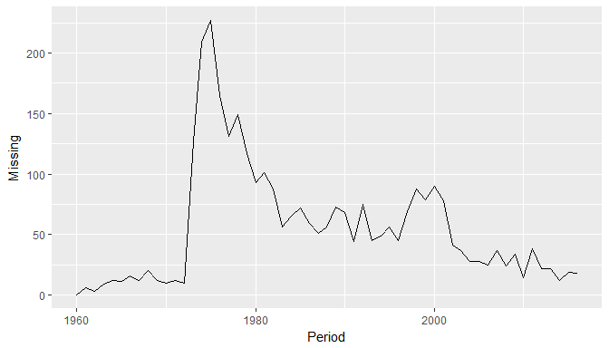

```r
missing = ME %>% group_by(Period) %>% summarise(Missing=sum(is.na(Size)))
missing.pct = ME %>% group_by(Period) %>% summarise(Missing=sum(is.na(Size))/n())
ggplot(missing, aes(x=Period, y=Missing)) + geom_line()
```

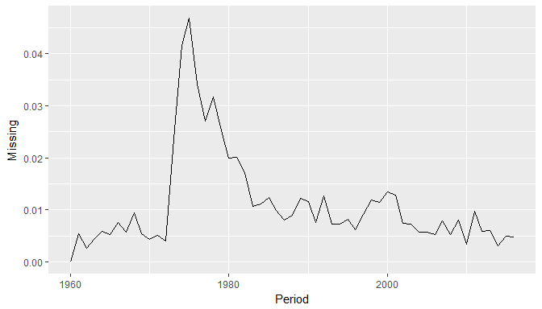

```r
ggplot(missing.pct, aes(x=Period, y=Missing)) + geom_line()
```

```r
dim(crsp)
```

```
## [1] 3117344      15
```

```r
crsp = left_join(crsp, ME, by=c("PERMNO", "Period"))
```

```r
ME = crsp %>% filter(Month==12) %>% select(PERMNO, Period, ME)
ME$Period = ME$Period + 1
ME$M = ME$ME
ME$ME = NULL
summary(ME)
```

```
##      PERMNO           Period           M
##  10145  :    57   Min.   :1961   Min.   :     0.0
##  10516  :    57   1st Qu.:1981   1st Qu.:    16.7
##  10866  :    57   Median :1992   Median :    72.3
##  10874  :    57   Mean   :1992   Mean   :  1431.0
##  10890  :    57   3rd Qu.:2002   3rd Qu.:   387.2
##  11308  :    57   Max.   :2017   Max.   :643120.1
##  (Other):262444                  NA's   :3461
```

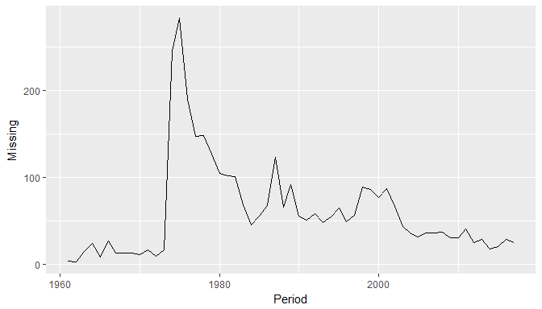

```r
missing = ME %>% group_by(Period) %>% summarise(Missing=sum(is.na(M)))
missing.pct = ME %>% group_by(Period) %>% summarise(Missing=sum(is.na(M))/n())
ggplot(missing, aes(x=Period, y=Missing)) + geom_line()
```

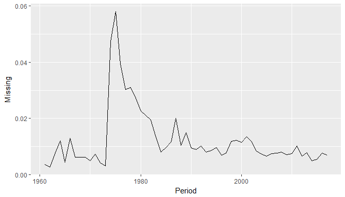

```r
ggplot(missing.pct, aes(x=Period, y=Missing)) + geom_line()
```

```r
crsp = left_join(crsp, ME, by=c("PERMNO", "Period"))
```

```r
dim(crsp)
```

```
## [1] 3117344      17
```

## 3.5 Prior Returns, $Prior$

```r
crsp$old.ri = crsp$ri
crsp$ri[is.null(crsp$ri)] = -.9999
crsp = crsp %>% group_by(PERMNO) %>%
    mutate(Prior.sum=
        lag(ri, 2) + lag(ri, 3) + lag(ri, 4) + lag(ri, 5) + lag(ri, 6) +
        lag(ri, 7) + lag(ri, 8) + lag(ri, 9) + lag(ri, 10) + lag(ri, 11) +
        lag(ri, 12),
        Prior.cum=log(
        (1+lag(ri, 2))*(1+lag(ri, 3))*(1+lag(ri, 4))*(1+lag(ri, 5))*(1+lag(ri, 6))*
        (1+lag(ri, 7))*(1+lag(ri, 8))*(1+lag(ri, 9))*(1+lag(ri, 10))*(1+lag(ri, 11))*
        (1+lag(ri, 12))),
        L13.price=lag(price, 13),
        L1.ri=lag(ri),
        L1.ME=lag(ME)
    ) %>% as.data.frame
crsp$ri = crsp$old.ri
crsp$old.ri = NULL

crsp$Prior = crsp$Prior.sum

summary(crsp %>% select(L1.ri, L13.price, Prior.sum, Prior.cum))
```

```
##      L1.ri         L13.price          Prior.sum        Prior.cum
##  Min.   :-1.00   Min.   : -1832.5   Min.   :-4.3     Min.   :-Inf
##  1st Qu.:-0.07   1st Qu.:     1.8   1st Qu.:-0.1     1st Qu.:-0.2
##  Median : 0.00   Median :    10.2   Median : 0.1     Median : 0.1
##  Mean   : 0.01   Mean   :    23.9   Mean   : 0.1     Mean   :-Inf
##  3rd Qu.: 0.07   3rd Qu.:    23.9   3rd Qu.: 0.4     3rd Qu.: 0.3
##  Max.   :24.00   Max.   :226000.0   Max.   :23.7     Max.   : 4.6
##  NA's   :65196   NA's   :322643     NA's   :352882   NA's   :352882
```

## 3.6 Adjusted Size

We hold portfolios for 12 months but the return each month will alter weights. We only need to do this once because we hold all annual portfolios for the same period. Monthly portfolios do not require a size adjustment.

```r
crsp = ri.adj.Size(crsp)
```

# 4 COMPUSTAT

```r
# Don't need to use colClasses here
comp = fread("C:/Data/CRSP/20171123_COMP_196001_201612.csv", showProgress=FALSE)
```

```r
comp$GVKEY = NULL

setnames(comp, c("LPERMNO"), c("PERMNO"))

comp$PERMNO = factor(comp$PERMNO)
comp$Date = as.Date(as.character(comp$datadate), "%Y%m%d")
```

## 4.1 Short Years

There should be no duplicate $PERMNO$-$fyear$ pairs (5 found). CRSP data has 287 083 rows and 54 columns.

```r
# duplicated will omit return FALSE for the first instance of a duplicated row
# calling from the top and the bottom ensure all instances are caught
pairs.ix = duplicated(comp[, c("PERMNO", "fyear")]) |
           duplicated(comp[, c("PERMNO", "fyear")], fromLast=TRUE)
comp[pairs.ix] %>% arrange(PERMNO, fyear, fyr)
```

| PERMNO | datadate | fyear | indfmt | consol | popsrc | datafmt | curcd | fyr | aco | act | ap | apc | arc | artfs | at | ceq | ch | che | cogs | cshpri | dlc | dp | drc | drlt | gp | invfg | invt | ivst | lct | … |
| --- | --- | --- | --- | --- | --- | --- | --- | --- | --- | --- | --- | --- | --- | --- | --- | --- | --- | --- | --- | --- | --- | --- | --- | --- | --- | --- | --- | --- | --- | --- |
| 22074 | 19870630 | 1987 | INDL | C | D | STD | USD | 6 | 44.777 | 140.682 | 0.000 | NA | NA | NA | 149.379 | 63.262 | 0.025 | 95.701 | 341.350 | 13.953 | 0.000 | 5.031 | NA | NA | 79.229 | 0.000 | 0.000 | 95.676 | 3.724 | … |
| 22074 | 19871231 | 1987 | INDL | C | D | STD | USD | 12 | 10.900 | 223.200 | 187.100 | NA | NA | NA | 1056.500 | 153.900 | NA | 3.300 | NA | NA | 3.000 | NA | NA | NA | NA | NA | 182.500 | NA | 310.300 | … |
| 67563 | 19980630 | 1998 | INDL | C | D | STD | USD | 6 | NA | NA | 10698.265 | NA | NA | NA | 18116.737 | 1234.060 | 311.278 | 485.478 | 716.058 | 52.354 | 4148.551 | 74.582 | NA | NA | 546.775 | NA | 70.182 | 174.200 | NA | … |
| 67563 | 19981231 | 1998 | INDL | C | D | STD | USD | 12 | NA | NA | 24620.066 | NA | NA | NA | 54868.984 | 1581.778 | 854.954 | 907.625 | 1859.545 | 79.557 | 12394.326 | 238.298 | NA | NA | 1057.442 | NA | 2446.651 | 52.671 | NA | … |
| 75228 | 19871031 | 1987 | INDL | C | D | STD | USD | 10 | 0.135 | 8.502 | 2.200 | NA | NA | NA | 17.970 | 7.217 | 0.790 | 0.790 | 8.045 | 3.936 | 6.935 | 0.228 | NA | NA | 5.446 | 2.392 | 3.748 | 0.000 | 10.374 | … |
| 75228 | 19871231 | 1987 | INDL | C | D | STD | USD | 12 | 1.840 | 14.113 | 3.342 | NA | NA | NA | 45.769 | 33.247 | 3.617 | 3.617 | 2.044 | 8.385 | 7.657 | 0.223 | NA | NA | 2.196 | 2.668 | 4.026 | 0.000 | 12.075 | … |
| 85531 | 19980630 | 1998 | INDL | C | D | STD | USD | 6 | NA | NA | NA | NA | NA | NA | NA | NA | NA | NA | 90.868 | 3.797 | NA | NA | NA | NA | 16.265 | NA | NA | NA | NA | … |
| 85531 | 19981231 | 1998 | INDL | C | D | STD | USD | 12 | 6.099 | 42.083 | 1.394 | NA | NA | NA | 91.463 | 53.380 | 20.439 | 20.439 | 177.740 | 11.172 | 0.067 | 3.923 | NA | NA | 31.632 | 0.000 | 0.000 | 0.000 | 30.043 | … |
| 88031 | 19900630 | 1990 | INDL | C | D | STD | USD | 6 | 0.000 | 1.571 | 0.000 | NA | NA | NA | 1.613 | 1.569 | NA | 1.571 | 0.089 | 1.257 | 0.000 | 0.000 | NA | NA | 0.043 | 0.000 | 0.000 | NA | 0.004 | … |
| 88031 | 19901231 | 1990 | INDL | C | D | STD | USD | 12 | 0.000 | 7.134 | 0.072 | NA | NA | NA | 7.139 | 6.924 | 7.116 | 7.116 | NA | NA | 0.000 | NA | NA | NA | NA | 0.000 | 0.000 | 0.000 | 0.178 | … |

```r
comp = comp %>% filter(!duplicated(comp[,c("PERMNO", "fyear")]))
```

## 4.2 Holding Period

```r
comp$Period = comp$fyear + 1
```

## 4.3 Book Equity, $BE$

```r
comp$ps = comp$pstkrv                                   # Redemption
comp$ps[is.na(comp$ps)] = comp$pstkl[is.na(comp$ps)]    # Liquidation
comp$ps[is.na(comp$ps)] = comp$pstk[is.na(comp$ps)]     # Book
comp$ps[is.na(comp$ps)] = 0

comp$txditc[is.na(comp$txditc)] = 0

# Asness and Frazzini use only seq

comp$BE = comp$seq + comp$txditc - comp$ps

comp$upstk[is.na(comp$upstk)] = 0

# Common Equity PLUS Par Value of Preferred Stock?
comp$BE[is.na(comp$BE)] = comp$ceq[is.na(comp$BE)] + comp$upstk[is.na(comp$BE)]

comp$BE[is.na(comp$BE)] = comp$at[is.na(comp$BE)] - comp$lt[is.na(comp$BE)]

comp = comp %>% group_by(PERMNO) %>% mutate(D1.BE=BE-lag(BE)) %>% as.data.frame

summary(comp[,c("BE", "D1.BE")])
```

```
##        BE               D1.BE
##  Min.   :-96620.0   Min.   :-99618.00
##  1st Qu.:    13.6   1st Qu.:    -1.02
##  Median :    63.3   Median :     2.92
##  Mean   :  1036.6   Mean   :    67.66
##  3rd Qu.:   309.8   3rd Qu.:    26.02
##  Max.   :359960.0   Max.   :223210.69
##  NA's   :19540      NA's   :43668
```

## 4.4 Operating Profit, $OP$

Compustat has $REVT$ and $SALE$ values.

```r
summary(comp %>% select(revt, sale))
```

```
##       revt               sale
##  Min.   :-15009.3   Min.   :-15009.3
##  1st Qu.:    25.5   1st Qu.:    25.5
##  Median :   114.2   Median :   114.2
##  Mean   :  1762.0   Mean   :  1762.0
##  3rd Qu.:   571.3   3rd Qu.:   571.3
##  Max.   :483521.0   Max.   :483521.0
##  NA's   :19880      NA's   :19880
```

Whichever one we use the expenses check is the same.

```r
expenses.OK = !is.na(comp$cogs) | !is.na(!comp$xsga) | !is.na(comp$xint)
comp$cogs[is.na(comp$cogs)] = 0
comp$xsga[is.na(comp$xsga)] = 0
comp$xint[is.na(comp$xint)] = 0

comp$op.revt.OK = !is.na(comp$revt) & expenses.OK
comp$op.sale.OK = !is.na(comp$sale) & expenses.OK

comp$OP.revt.OK = (comp$BE > 0) & comp$op.revt.OK
comp$OP.sale.OK = (comp$BE > 0) & comp$op.sale.OK

comp$OP.revt.OK[is.na(comp$OP.revt.OK)] = FALSE
comp$OP.sale.OK[is.na(comp$OP.sale.OK)] = FALSE

comp$OP.revt = (comp$revt - comp$cogs - comp$xsga - comp$xint)/comp$BE
comp$OP.sale = (comp$sale - comp$cogs - comp$xsga - comp$xint)/comp$BE

summary(comp %>% select(OP.revt, OP.sale))
```

```
##     OP.revt         OP.sale
##  Min.   : -Inf   Min.   : -Inf
##  1st Qu.:0.057   1st Qu.:0.057
##  Median :0.196   Median :0.196
##  Mean   :  NaN   Mean   :  NaN
##  3rd Qu.:0.315   3rd Qu.:0.315
##  Max.   :  Inf   Max.   :  Inf
##  NA's   :20724   NA's   :20724
```

```r
summary(comp$OP.revt[comp$OP.revt.OK])
```

```
##      Min.   1st Qu.    Median      Mean   3rd Qu.      Max.
## -1941.000     0.062     0.196     0.132     0.310  9424.000
```

```r
summary(comp$OP.sale[comp$OP.sale.OK])
```

```
##      Min.   1st Qu.    Median      Mean   3rd Qu.      Max.
## -1941.000     0.062     0.196     0.132     0.310  9424.000
```

```r
comp %>% select(revt, OP.revt, sale, OP.sale) %>% filter(revt!=sale) %>% head %>% round(3)
```

| revt | OP.revt | sale | OP.sale |
| --- | --- | --- | --- |

They seem to be the same.

```r
comp$op.OK = comp$op.revt.OK
comp$OP.OK = comp$OP.revt.OK
comp$OP = comp$OP.revt
```

### 4.4.1 RnD

```r
summary(comp$xrd)
```

```
##     Min.  1st Qu.   Median     Mean  3rd Qu.     Max.     NA's
##    -0.65     0.10     2.30    68.56    15.64 16080.00   162030
```

```r
comp$xrd[is.na(comp$xrd)] = 0
comp$OP.2 = (comp$revt - comp$cogs - comp$xsga - comp$xint + comp$xrd)/comp$BE
summary(comp %>% filter(OP.OK) %>% select(OP, OP.2))
```

```
##        OP                 OP.2
##  Min.   :-1941.333   Min.   :-945.333
##  1st Qu.:    0.062   1st Qu.:   0.092
##  Median :    0.196   Median :   0.223
##  Mean   :    0.132   Mean   :   0.255
##  3rd Qu.:    0.310   3rd Qu.:   0.346
##  Max.   : 9423.750   Max.   :9423.750
```

## 4.5 Gross Profit, $GP$

```r
comp$GP = comp$gp / comp$at
summary(comp$GP)
```

```
##    Min. 1st Qu.  Median    Mean 3rd Qu.    Max.    NA's
##    -Inf   0.097   0.266     NaN   0.460     Inf   20236
```

```r
ix = is.na(comp$GP)
comp$GP[ix] = (comp$revt[ix] - comp$cogs[ix]) / comp$at[ix]
comp$GP[is.infinite(comp$GP)] = NA
summary(comp$GP)
```

```
##     Min.  1st Qu.   Median     Mean  3rd Qu.     Max.     NA's
## -134.200    0.097    0.266    0.308    0.460  227.400    20006
```

## 4.6 Cash Profit, $CP$

```r
summary(comp %>% select(rect, xpp, ap, invt, drc, xacc))
```

```
##       rect                xpp                 ap
##  Min.   :      0.0   Min.   :    0.00   Min.   :      0.0
##  1st Qu.:      3.9   1st Qu.:    0.00   1st Qu.:      1.9
##  Median :     21.4   Median :    0.02   Median :      9.5
##  Mean   :   1678.8   Mean   :   14.81   Mean   :   1603.4
##  3rd Qu.:    142.3   3rd Qu.:    1.06   3rd Qu.:     76.1
##  Max.   :2080955.3   Max.   :20091.00   Max.   :1974374.5
##  NA's   :26245       NA's   :129342     NA's   :31584
##       invt               drc                xacc
##  Min.   :    -2.7   Min.   :    0.00   Min.   :  -20.27
##  1st Qu.:     0.3   1st Qu.:    0.00   1st Qu.:    1.09
##  Median :     6.9   Median :    0.00   Median :    5.63
##  Mean   :   307.3   Mean   :   50.83   Mean   :  110.61
##  3rd Qu.:    47.3   3rd Qu.:    4.31   3rd Qu.:   31.85
##  Max.   :472266.2   Max.   :27468.00   Max.   :65614.00
##  NA's   :26346      NA's   :217718     NA's   :99451
```

```r
apply(
    comp %>% select(rect, xpp, ap, invt, drc, xacc),
    2,
    function(x) sum(is.na(x)/length(x)*100)
) %>% round(2)
```

```
##  rect   xpp    ap  invt   drc  xacc
##  9.14 45.05 11.00  9.18 75.84 34.64
```

Let’s assume for now that firms don’t need all of these values. We’ll set everything that is missing, except $revt$ and $ap$, to 0. This essentially requires firms to have both Receivables and Payables to consider their accruals.

```r
comp$xpp[is.na(comp$xpp)] = 0
comp$invt[is.na(comp$invt)] = 0
comp$drc[is.na(comp$drc)] = 0
comp$xacc[is.na(comp$xacc)] = 0
```

```r
comp = comp %>% group_by(PERMNO) %>% mutate(
    D1.rect=rect-lag(rect), D1.xpp=xpp-lag(xpp),
    D1.ap=ap-lag(ap), D1.invt=invt-lag(invt),
    D1.drc=drc-lag(drc), D1.xacc=xacc-lag(xacc)
) %>% as.data.frame
```

```r
summary(comp %>% select(D1.rect, D1.xpp, D1.ap, D1.invt, D1.drc, D1.xacc))
```

```
##     D1.rect              D1.xpp               D1.ap
##  Min.   :-600169.0   Min.   :-10503.170   Min.   :-662237.4
##  1st Qu.:     -0.6   1st Qu.:     0.000   1st Qu.:     -0.5
##  Median :      0.9   Median :     0.000   Median :      0.4
##  Mean   :    100.2   Mean   :     0.373   Mean   :    108.9
##  3rd Qu.:     10.5   3rd Qu.:     0.000   3rd Qu.:      5.8
##  Max.   : 709139.0   Max.   :  6937.000   Max.   : 580318.3
##  NA's   :50375       NA's   :25137        NA's   :55590
##     D1.invt              D1.drc             D1.xacc
##  Min.   :-379695.5   Min.   :-5280.000   Min.   :-65614.00
##  1st Qu.:     -0.1   1st Qu.:    0.000   1st Qu.:     0.00
##  Median :      0.0   Median :    0.000   Median :     0.00
##  Mean   :     16.0   Mean   :    1.647   Mean   :     4.26
##  3rd Qu.:      2.5   3rd Qu.:    0.000   3rd Qu.:     0.86
##  Max.   : 224230.5   Max.   :12323.000   Max.   : 44511.00
##  NA's   :25137       NA's   :25137       NA's   :25137
```

```r
apply(
    comp %>% select(D1.rect, D1.xpp, D1.ap, D1.invt, D1.drc, D1.xacc),
    2,
    function(x) sum(is.na(x)/length(x)*100)
) %>% round(2)
```

```
## D1.rect  D1.xpp   D1.ap D1.invt  D1.drc D1.xacc
##   17.55    8.76   19.36    8.76    8.76    8.76
```

```r
comp = comp %>% mutate(OP.AccFama=D1.rect+D1.xpp-D1.ap-D1.invt-D1.drc-D1.xacc)
comp = comp %>% mutate(OP.Acc=-D1.rect-D1.invt-D1.xpp+D1.drc+D1.ap+D1.xacc)
summary(comp %>% select(OP.AccFama, OP.Acc))
```

```
##    OP.AccFama            OP.Acc
##  Min.   :-702558.3   Min.   :-403256.0
##  1st Qu.:     -8.2   1st Qu.:     -7.9
##  Median :     -0.3   Median :     -0.4
##  Mean   :    -32.0   Mean   :     -4.0
##  3rd Qu.:      3.4   3rd Qu.:      3.5
##  Max.   : 394654.8   Max.   : 704184.1
##  NA's   :61215       NA's   :61215
```

Now for years with missing accruals we don’t want this to alter the non-missing operating profits we have.

```r
comp$OP.Acc[is.na(comp$OP.Acc)] = 0
summary(comp$OP.Acc)
```

```
##      Min.   1st Qu.    Median      Mean   3rd Qu.      Max.
## -403300.0      -4.0       0.0      -3.1       1.3  704200.0
```

```r
comp$CP = (comp$revt-comp$cogs-comp$xsga-comp$xint+comp$xrd+comp$OP.Acc)/comp$BE
summary(comp %>% filter(OP.OK) %>% select(OP, OP.2, GP, CP))
```

```
##        OP                 OP.2                GP
##  Min.   :-1941.333   Min.   :-945.333   Min.   :-31.58693
##  1st Qu.:    0.062   1st Qu.:   0.092   1st Qu.:  0.09808
##  Median :    0.196   Median :   0.223   Median :  0.26675
##  Mean   :    0.132   Mean   :   0.255   Mean   :  0.31175
##  3rd Qu.:    0.310   3rd Qu.:   0.346   3rd Qu.:  0.45893
##  Max.   : 9423.750   Max.   :9423.750   Max.   :227.44910
##                                         NA's   :12
##        CP
##  Min.   :-1270.000
##  1st Qu.:    0.042
##  Median :    0.200
##  Mean   :    0.283
##  3rd Qu.:    0.352
##  Max.   : 8683.125
##
```

## 4.7 Accruals, $Ac$

```r
summary(comp %>% select(act, ch, lct, dlc))
```

```
##       act                  ch                lct
##  Min.   :     0.00   Min.   :  -279.1   Min.   :     0.0
##  1st Qu.:    13.50   1st Qu.:     1.3   1st Qu.:     5.7
##  Median :    54.11   Median :     7.7   Median :    23.6
##  Mean   :   649.02   Mean   :   247.7   Mean   :   495.2
##  3rd Qu.:   237.83   3rd Qu.:    46.0   3rd Qu.:   120.9
##  Max.   :161978.00   Max.   :380619.4   Max.   :329795.0
##  NA's   :62161       NA's   :50779      NA's   :58554
##       dlc
##  Min.   : -3753.5
##  1st Qu.:     0.1
##  Median :     2.4
##  Mean   :   549.8
##  3rd Qu.:    21.2
##  Max.   :575319.4
##  NA's   :21507
```

We will require that firms have both current assets and liabilities.

```r
comp$ch[is.na(comp$ch)] = 0
comp$dlc[is.na(comp$dlc)] = 0

comp$WC = comp$act - comp$ch - comp$lct + comp$dlc
comp = comp %>% group_by(PERMNO) %>% mutate(D1.WC=WC-lag(WC)) %>% as.data.frame

comp$Acc = comp$D1.WC / comp$BE

comp$Acc[is.infinite(comp$Acc)] = 0

summary(comp$Acc[comp$BE>0])
```

```
##    Min. 1st Qu.  Median    Mean 3rd Qu.    Max.    NA's
## -713.50   -0.06    0.02   -0.03    0.11 2317.00   82093
```

## 4.8 Investment, $INV$

```r
comp = comp %>% group_by(PERMNO) %>% mutate(INV=(at-lag(at))/lag(at)) %>%
    as.data.frame
comp$INV[(comp$INV==Inf) | (comp$INV==-Inf)] = NA
summary(comp$INV)
```

```
##    Min. 1st Qu.  Median    Mean 3rd Qu.    Max.    NA's
##   -1.00   -0.03    0.07    0.22    0.19 7898.00   42930
```

Makes more sense to define investment as the change in PPE plus depreciation.

```r
comp = comp %>% group_by(PERMNO) %>%
    mutate(INV.ppe=(ppent-lag(ppent)+dp)/lag(ppent)) %>%
    as.data.frame
comp$INV.ppe[(comp$INV.ppe==Inf) | (comp$INV.ppe==-Inf)] = NA
summary(comp$INV.ppe)
```

```
##     Min.  1st Qu.   Median     Mean  3rd Qu.     Max.     NA's
##    -1.00     0.11     0.24     1.77     0.50 74240.00    60234
```

## 4.9 Missing Values

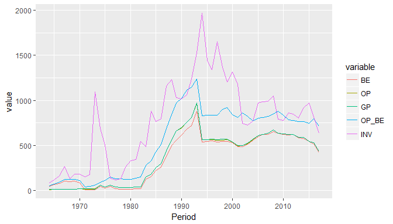

```r
missing = comp %>% filter(Date>as.Date("1963-06-30")) %>%
    group_by(Period) %>% summarise(
        BE=sum(is.na(BE)),
        OP=sum(!op.OK),
        GP=sum(is.na(GP)),
        OP_BE=sum(!OP.OK),
        INV=sum(is.na(INV))
) %>% melt(id="Period") %>% filter(!is.na(Period))

ggplot(missing, aes(x=Period, color=variable)) + geom_line(aes(y=value))
```

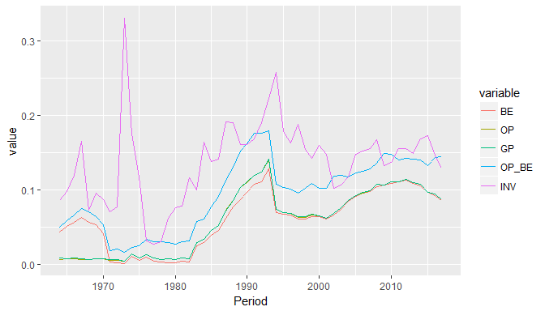

```r
missing = comp %>% filter(Date>as.Date("1963-06-30")) %>%
    group_by(Period) %>% summarise(
        BE=sum(is.na(BE))/n(),
        OP=sum(!op.OK)/n(),
        GP=sum(is.na(GP))/n(),
        OP_BE=sum(!OP.OK)/n(),
        INV=sum(is.na(INV))/n()
) %>% melt(id="Period") %>% filter(!is.na(Period))

ggplot(missing, aes(x=Period, color=variable)) + geom_line(aes(y=value))
```

# 5 Univariate Sorts

## 5.1 $Size$

- Annual rebalance

```r
df = combine.sources(crsp, comp)
```

### 5.1.1 $ME$ Decile Breakpoints

```r
quantiles = 1:10/10

nyse = df %>% filter(Exchange=="NYSE", !is.na(ME)) %>% select(Date, PERMNO, ME)

breakpoints = nyse %>% arrange(Date, ME) %>% group_by(Date) %>% summarize(
    D10=ME[.1*n()], D20=ME[.2*n()],
    D30=ME[.3*n()], D40=ME[.4*n()],
    D50=ME[.5*n()], D60=ME[.6*n()],
    D70=ME[.7*n()], D80=ME[.8*n()],
    D90=ME[.9*n()], D100=ME[n()]) %>% as.data.frame
write.csv(breakpoints, "C:/Data/Thesis/ME_Decile_Breakpoints.csv")
```

### 5.1.2 $Size$ Deciles

```r
quantiles = 1:10/10

nyse = df %>% filter(
    Exchange=="NYSE", Month==7, !is.na(Size)
    ) %>% select(Period, PERMNO, Size)

breakpoints = nyse %>% arrange(Period, Size) %>% group_by(Period) %>% summarize(
    D10=Size[.1*n()], D20=Size[.2*n()],
    D30=Size[.3*n()], D40=Size[.4*n()],
    D50=Size[.5*n()], D60=Size[.6*n()],
    D70=Size[.7*n()], D80=Size[.8*n()],
    D90=Size[.9*n()], D100=Size[n()]) %>% as.data.frame

breakpoints$Period = breakpoints$Period + 1

breakpoints[, c("PERMNO", "Size")] = NULL

df = left_join(df, breakpoints, by=c("Period"))
```

```r
df = assign.bkts(df, "Size", quantiles)
```

```r
df %>% group_by(Size.B, Date) %>% summarize(N=n()) %>% group_by(Size.B) %>%
    summarise(avg.N=mean(N))
```

| Size.B | avg.N |
| --- | --- |
| 1 | 2106.2461 |
| 2 | 561.3692 |
| 3 | 372.4221 |
| 4 | 300.3925 |
| 5 | 247.8287 |
| 6 | 210.9003 |
| 7 | 191.6822 |
| 8 | 182.4268 |
| 9 | 166.5312 |
| 10 | 169.7383 |

[output cut: 1 more lines]

$Size$ adjusted for last month’s return

```r
# df = ri.adj.Size(df)

df = df %>% group_by(Size.B, Date) %>% mutate(
    adj.bkt.Size=sum(adj.Size, na.rm=TRUE)
) %>% as.data.frame
df$wt.ri = df$ri * df$adj.Size / df$adj.bkt.Size
```

### 5.1.3 Returns

```r
decile.returns = df %>%
    dcast(Date ~ Size.B, fun.aggregate=sum, value.var="wt.ri", na.rm=TRUE)
write.csv(decile.returns, "C:/Data/Thesis/Size_Decile_Returns.csv")
round(colMeans(decile.returns %>% select(-Date)) * 100, 2)
```

```
##    1    2    3    4    5    6    7    8    9   10   NA
## 1.15 1.10 1.12 1.10 1.10 1.05 1.05 1.04 0.96 0.83 0.44
```

## 5.2 $BM$ (Annual, Lagged)

- Annual rebalance

```r
df = combine.sources(crsp, comp)
df = df %>% filter(!is.na(BM), !is.na(Size), BE>0)
```

### 5.2.1 $BM$ Decile Breakpoints

```r
quantiles = 1:10/10

nyse = df %>% filter(Exchange=="NYSE", Month==7) %>% select(Period, PERMNO, BM)

breakpoints = nyse %>% arrange(Period, BM) %>% group_by(Period) %>% summarize(
    D10=BM[.1*n()], D20=BM[.2*n()],
    D30=BM[.3*n()], D40=BM[.4*n()],
    D50=BM[.5*n()], D60=BM[.6*n()],
    D70=BM[.7*n()], D80=BM[.8*n()],
    D90=BM[.9*n()], D100=BM[n()]) %>% as.data.frame
write.csv(breakpoints, "C:/Data/Thesis/BM_Decile_Breakpoints.csv")

breakpoints$Period = breakpoints$Period + 1

breakpoints[, c("PERMNO", "BM")] = NULL

df = left_join(df, breakpoints, by=c("Period"))

df = assign.bkts(df, "BM", quantiles)
```

```r
df %>% group_by(BM.B, Date) %>% summarize(N=n()) %>% group_by(BM.B) %>%
    summarise(avg.N=mean(N))
```

| BM.B | avg.N |
| --- | --- |
| 1 | 600.81776 |
| 2 | 399.37850 |
| 3 | 353.13084 |
| 4 | 333.83489 |
| 5 | 310.41745 |
| 6 | 310.24299 |
| 7 | 309.64174 |
| 8 | 327.11059 |
| 9 | 363.24611 |
| 10 | 505.99688 |

[output cut: 1 more lines]

```r
# df = ri.adj.Size(df)

df = df %>% group_by(BM.B, Date) %>% mutate(
    adj.bkt.Size=sum(adj.Size, na.rm=TRUE)
) %>% as.data.frame
df$wt.ri = df$ri * df$adj.Size / df$adj.bkt.Size
```

### 5.2.2 Returns

```r
decile.returns = df %>%
    dcast(Date ~ BM.B, fun.aggregate=sum, value.var="wt.ri", na.rm=TRUE)
write.csv(decile.returns, "C:/Data/Thesis/BM_Decile_Returns.csv")
round(colMeans(decile.returns %>% select(-Date)) * 100, 2)
```

```
##    1    2    3    4    5    6    7    8    9   10   NA
## 0.81 0.92 0.90 0.88 1.04 0.98 0.99 1.10 1.06 1.15 1.22
```

### 5.2.3 $ME$

```r
df %>% group_by(BM.B, Date) %>% summarise(avg.ME=mean(ME, na.rm=TRUE)) %>%
    group_by(BM.B) %>% summarise(avg.ME=mean(avg.ME)) %>% round(2)
```

| BM.B | avg.ME |
| --- | --- |
| 1 | 2883.84 |
| 2 | 2704.91 |
| 3 | 2233.62 |
| 4 | 1888.02 |
| 5 | 1503.88 |
| 6 | 1400.40 |
| 7 | 1054.26 |
| 8 | 973.99 |
| 9 | 817.43 |
| 10 | 530.22 |

[output cut: 1 more lines]

### 5.2.4 $Size$

```r
df %>% group_by(BM.B, Date) %>% summarise(avg.Size=mean(Size, na.rm=TRUE)) %>%
    group_by(BM.B) %>% summarise(avg.Size=mean(avg.Size)) %>% round(2)
```

| BM.B | avg.Size |
| --- | --- |
| 1 | 2792.68 |
| 2 | 2596.04 |
| 3 | 2154.33 |
| 4 | 1822.38 |
| 5 | 1432.28 |
| 6 | 1360.15 |
| 7 | 1016.14 |
| 8 | 937.60 |
| 9 | 786.40 |
| 10 | 502.26 |

[output cut: 1 more lines]

### 5.2.5 $Prior$

```r
df %>% group_by(BM.B, Date) %>% summarise(avg.Prior=mean(Prior, na.rm=TRUE)) %>%
    group_by(BM.B) %>% summarise(avg.Prior=mean(avg.Prior)) %>% round(2)
```

| BM.B | avg.Prior |
| --- | --- |
| 1 | 0.14 |
| 2 | 0.13 |
| 3 | 0.13 |
| 4 | 0.12 |
| 5 | 0.13 |
| 6 | 0.13 |
| 7 | 0.14 |
| 8 | 0.14 |
| 9 | 0.15 |
| 10 | 0.17 |

[output cut: 1 more lines]

## 5.3 Forecasting $BE$

We want to distinguish between changes in price and changes in expected $BE$.

Exhibit 4 from Asness and Frazzini (2013).

$$BM_t = \beta_0 + \beta_1\cdot BM_{t-1} + \beta_2\cdot BM_{t-1}^{Current ME}$$

```r
df = combine.sources(crsp, comp)
df = df %>% filter(!is.na(BM), Month==7)
```

```r
df = df %>% group_by(PERMNO) %>% mutate(
    L1.BM=lag(BM),
    L1.BMC=lag(BMC),
    L1.BMC_L1.BM=L1.BMC-L1.BM) %>% as.data.frame
```

```r
summary(df %>% select(PERMNO, L1.BM, L1.BMC, L1.BMC_L1.BM))
```

```
##     PERMNO              L1.BM              L1.BMC
##  Length:219931      Min.   :-906.639   Min.   :-222.335
##  Class :character   1st Qu.:   0.350   1st Qu.:   0.327
##  Mode  :character   Median :   0.654   Median :   0.624
##                     Mean   :   0.860   Mean   :   0.818
##                     3rd Qu.:   1.116   3rd Qu.:   1.063
##                     Max.   : 294.428   Max.   : 202.201
##                     NA's   :20089      NA's   :20248
##   L1.BMC_L1.BM
##  Min.   :-194.602
##  1st Qu.:  -0.144
##  Median :  -0.024
##  Mean   :  -0.042
##  3rd Qu.:   0.067
##  Max.   : 850.603
##  NA's   :20248
```

```r
formula.str = "BM ~ L1.BM + L1.BMC_L1.BM"
results = c()
for (period in 1964:2016){
    dt = df %>% filter(Period==period)
    results = rbind(results, lm(formula(formula.str), data=dt)$coefficients)
}

results = as.data.frame(results)
results$diff = results$L1.BM - results$L1.BMC_L1.BM

rbind(sapply(results, mean), sapply(results, se), sapply(results, t.stat))
```

```
##      (Intercept)       L1.BM L1.BMC_L1.BM       diff
## [1,]  0.04855788  0.97065682   0.86610139 0.10455543
## [2,]  0.04379389  0.06168029   0.09389111 0.06856677
## [3,]  1.10878220 15.73690546   9.22453024 1.52487034
```

## 5.4 $\Delta log(Book Price/Share)$

Exhibit 5 from Asness and Frazzini (2013).

We want to forecast unobserved changes in book value per share. Regress changes in book value per share on the lagged prior returns. Prior returns are already lagged but the change in book value per share uses a lag. Also see Sloan et al. (2017).

```r
df = combine.sources(crsp, comp)

df$bp = log(df$BE / df$shares)

df = df %>% filter(!is.na(bp), !is.infinite(bp), Month==7) %>% group_by(PERMNO) %>%
    mutate(D1.bp=bp-lag(bp), L1.Prior=lag(Prior.cum)) %>% as.data.frame
```

```r
summary(df %>% select(PERMNO, Period, D1.bp, L1.Prior))
```

```
##     PERMNO              Period         D1.bp            L1.Prior
##  Length:214896      Min.   :1962   Min.   :-10.017   Min.   :-6.190
##  Class :character   1st Qu.:1983   1st Qu.: -0.089   1st Qu.:-0.194
##  Mode  :character   Median :1994   Median :  0.052   Median : 0.061
##                     Mean   :1993   Mean   :  0.005   Mean   : 0.033
##                     3rd Qu.:2003   3rd Qu.:  0.142   3rd Qu.: 0.291
##                     Max.   :2016   Max.   :  8.555   Max.   : 3.819
##                                    NA's   :19932     NA's   :29631
```

```r
df %>% group_by(Period) %>% summarise(N=n())
```

| Period | N |
| --- | --- |
| 1962 | 518 |
| 1963 | 916 |
| 1964 | 1002 |
| 1965 | 1097 |
| 1966 | 1231 |
| 1967 | 1453 |
| 1968 | 1546 |
| 1969 | 1704 |
| 1970 | 1869 |
| 1971 | 1999 |

[output cut: 45 more lines]

```r
formula.str = "D1.bp ~ L1.Prior"

results = c()
for (period in 1964:2016){
    dt = df %>% filter(Period==period)
    results = rbind(results, lm(formula(formula.str), data=dt)$coefficients)
}

results = as.data.frame(results)

rbind(sapply(results, mean), sapply(results, se), sapply(results, t.stat))
```

```
##      (Intercept)   L1.Prior
## [1,] 0.000670307  0.1803592
## [2,] 0.006073168  0.0116269
## [3,] 0.110371889 15.5122378
```

## 5.5 $BM_C$ (Annual, Current)

- Annual rebalance

```r
df = combine.sources(crsp, comp)
df = df %>% filter(!is.na(BMC), !is.na(Size), BE>0)
```

### 5.5.1 $BM$ Decile Breakpoints

```r
quantiles = 1:10/10

nyse = df %>% filter(Exchange=="NYSE", Month==7) %>% select(Period, PERMNO, BMC)

breakpoints = nyse %>% arrange(Period, BMC) %>% group_by(Period) %>% summarize(
    D10=BMC[.1*n()], D20=BMC[.2*n()],
    D30=BMC[.3*n()], D40=BMC[.4*n()],
    D50=BMC[.5*n()], D60=BMC[.6*n()],
    D70=BMC[.7*n()], D80=BMC[.8*n()],
    D90=BMC[.9*n()], D100=BMC[n()]) %>% as.data.frame
write.csv(breakpoints, "C:/Data/Thesis/BMC_Decile_Breakpoints.csv")

breakpoints$Period = breakpoints$Period + 1

breakpoints[, c("PERMNO", "BMC")] = NULL

df = left_join(df, breakpoints, by=c("Period"))

df = assign.bkts(df, "BMC", quantiles)
```

```r
df %>% group_by(BMC.B, Date) %>% summarize(N=n()) %>% group_by(BMC.B) %>%
    summarise(avg.N=mean(N))
```

| BMC.B | avg.N |
| --- | --- |
| 1 | 610.18536 |
| 2 | 383.19470 |
| 3 | 349.38941 |
| 4 | 329.30841 |
| 5 | 322.72430 |
| 6 | 319.99221 |
| 7 | 321.06542 |
| 8 | 335.71807 |
| 9 | 367.13396 |
| 10 | 491.49688 |

[output cut: 1 more lines]

```r
# df = ri.adj.Size(df)

df = df %>% group_by(BMC.B, Date) %>% mutate(
    adj.bkt.Size=sum(adj.Size, na.rm=TRUE)
) %>% as.data.frame
df$wt.ri = df$ri * df$adj.Size / df$adj.bkt.Size
```

### 5.5.2 Returns

```r
decile.returns = df %>%
    dcast(Date ~ BMC.B, fun.aggregate=sum, value.var="wt.ri", na.rm=TRUE)
write.csv(decile.returns, "C:/Data/Thesis/BMC_Decile_Returns.csv")
round(colMeans(decile.returns %>% select(-Date)) * 100, 2)
```

```
##    1    2    3    4    5    6    7    8    9   10   NA
## 0.84 0.88 0.94 0.92 0.86 1.02 0.94 1.09 1.13 1.19 0.30
```

### 5.5.3 $ME$

```r
df %>% group_by(BMC.B, Date) %>% summarise(avg.ME=mean(ME, na.rm=TRUE)) %>%
    group_by(BMC.B) %>% summarise(avg.ME=mean(avg.ME)) %>% round(2)
```

| BMC.B | avg.ME |
| --- | --- |
| 1 | 2842.99 |
| 2 | 2661.47 |
| 3 | 2419.74 |
| 4 | 1819.49 |
| 5 | 1685.96 |
| 6 | 1306.59 |
| 7 | 1156.71 |
| 8 | 927.94 |
| 9 | 688.50 |
| 10 | 521.69 |

[output cut: 1 more lines]

### 5.5.4 $Size$

```r
df %>% group_by(BMC.B, Date) %>% summarise(avg.Size=mean(Size, na.rm=TRUE)) %>%
    group_by(BMC.B) %>% summarise(avg.Size=mean(avg.Size)) %>% round(2)
```

| BMC.B | avg.Size |
| --- | --- |
| 1 | 2751.66 |
| 2 | 2567.18 |
| 3 | 2338.13 |
| 4 | 1756.02 |
| 5 | 1630.66 |
| 6 | 1270.96 |
| 7 | 1119.02 |
| 8 | 895.46 |
| 9 | 670.79 |
| 10 | 490.23 |

[output cut: 1 more lines]

### 5.5.5 $Prior$

```r
df %>% group_by(BMC.B, Date) %>% summarise(avg.Prior=mean(Prior, na.rm=TRUE)) %>%
    group_by(BMC.B) %>% summarise(avg.Prior=mean(avg.Prior)) %>% round(2)
```

| BMC.B | avg.Prior |
| --- | --- |
| 1 | 0.28 |
| 2 | 0.20 |
| 3 | 0.17 |
| 4 | 0.15 |
| 5 | 0.13 |
| 6 | 0.12 |
| 7 | 0.10 |
| 8 | 0.09 |
| 9 | 0.08 |
| 10 | 0.02 |

[output cut: 1 more lines]

## 5.6 $BM_M$ (Monthly, Current)

- Monthly rebalance

```r
df = combine.sources(crsp, comp)
df = df %>% filter(!is.na(BMM), !is.na(L1.ME), BE>0)
```

### 5.6.1 $BMM$ Decile Breakpoints

```r
quantiles = 1:10/10

nyse = df %>% filter(Exchange=="NYSE") %>% select(Date, PERMNO, BMM)

breakpoints = nyse %>% arrange(Date, BMM) %>% group_by(Date) %>% summarize(
    D10=BMM[.1*n()], D20=BMM[.2*n()],
    D30=BMM[.3*n()], D40=BMM[.4*n()],
    D50=BMM[.5*n()], D60=BMM[.6*n()],
    D70=BMM[.7*n()], D80=BMM[.8*n()],
    D90=BMM[.9*n()], D100=BMM[n()]) %>% as.data.frame
write.csv(breakpoints, "C:/Data/Thesis/BMM_Decile_Breakpoints.csv")

# breakpoints$Period = breakpoints$Period + 1

breakpoints[, c("PERMNO", "BMM")] = NULL

df = left_join(df, breakpoints, by=c("Date"))

df = assign.bkts(df, "BMM", quantiles)
```

```r
df %>% group_by(BMM.B, Date) %>% summarize(N=n()) %>% group_by(BMM.B) %>%
    summarise(avg.N=mean(N))
```

| BMM.B | avg.N |
| --- | --- |
| 1 | 545.558104 |
| 2 | 367.223242 |
| 3 | 338.117737 |
| 4 | 325.350153 |
| 5 | 324.123853 |
| 6 | 329.172783 |
| 7 | 333.175841 |
| 8 | 349.047401 |
| 9 | 383.732416 |
| 10 | 481.946483 |

[output cut: 1 more lines]

```r
# df = ri.adj.Size(df)

df = df %>% group_by(BMM.B, Date) %>% mutate(
    bkt.L1.ME=sum(L1.ME, na.rm=TRUE)
) %>% as.data.frame
df$wt.ri = df$ri * df$L1.ME / df$bkt.L1.ME
```

### 5.6.2 Returns

```r
decile.returns = df %>%
    dcast(Date ~ BMM.B, fun.aggregate=sum, value.var="wt.ri", na.rm=TRUE)
write.csv(decile.returns, "C:/Data/Thesis/BMM_Decile_Returns.csv")
round(colMeans(decile.returns %>% select(-Date)) * 100, 2)
```

```
##    1    2    3    4    5    6    7    8    9   10   NA
## 0.90 0.89 0.91 0.93 0.97 1.05 1.02 1.18 1.27 1.33 3.95
```

### 5.6.3 $ME$

```r
df %>% group_by(BMM.B, Date) %>% summarise(avg.ME=mean(ME, na.rm=TRUE)) %>%
    group_by(BMM.B) %>% summarise(avg.ME=mean(avg.ME)) %>% round(2)
```

| BMM.B | avg.ME |
| --- | --- |
| 1 | 2880.98 |
| 2 | 2766.78 |
| 3 | 2251.22 |
| 4 | 1960.83 |
| 5 | 1578.19 |
| 6 | 1398.45 |
| 7 | 1118.28 |
| 8 | 928.30 |
| 9 | 705.73 |
| 10 | 420.14 |

[output cut: 1 more lines]

### 5.6.4 $Size$

```r
df %>% group_by(BMM.B, Date) %>% summarise(avg.Size=mean(Size, na.rm=TRUE)) %>%
    group_by(BMM.B) %>% summarise(avg.Size=mean(avg.Size)) %>% round(2)
```

| BMM.B | avg.Size |
| --- | --- |
| 1 | 2665.05 |
| 2 | 2632.21 |
| 3 | 2157.54 |
| 4 | 1895.31 |
| 5 | 1534.03 |
| 6 | 1369.07 |
| 7 | 1106.04 |
| 8 | 935.07 |
| 9 | 730.61 |
| 10 | 451.29 |

[output cut: 1 more lines]

### 5.6.5 $Prior$

```r
df %>% group_by(BMM.B, Date) %>% summarise(avg.Prior=mean(Prior, na.rm=TRUE)) %>%
    group_by(BMM.B) %>% summarise(avg.Prior=mean(avg.Prior)) %>% round(2)
```

| BMM.B | avg.Prior |
| --- | --- |
| 1 | 0.40 |
| 2 | 0.25 |
| 3 | 0.20 |
| 4 | 0.17 |
| 5 | 0.14 |
| 6 | 0.11 |
| 7 | 0.09 |
| 8 | 0.06 |
| 9 | 0.01 |
| 10 | -0.13 |

[output cut: 1 more lines]

## 5.7 $OP$

- Annual rebalance

```r
df = combine.sources(crsp, comp)
df = df %>% filter(OP.OK, !is.na(Size))
```

### 5.7.1 $OP$ Decile Breakpoints

```r
quantiles = 1:10/10

nyse = df %>% filter(Exchange=="NYSE", Month==7) %>% select(Period, PERMNO, OP)

breakpoints = nyse %>% arrange(Period, OP) %>% group_by(Period) %>% summarize(
    D10=OP[.1*n()], D20=OP[.2*n()],
    D30=OP[.3*n()], D40=OP[.4*n()],
    D50=OP[.5*n()], D60=OP[.6*n()],
    D70=OP[.7*n()], D80=OP[.8*n()],
    D90=OP[.9*n()], D100=OP[n()]) %>% as.data.frame
write.csv(breakpoints, "C:/Data/Thesis/OP_Decile_Breakpoints.csv")

breakpoints$Period = breakpoints$Period + 1

breakpoints[, c("PERMNO", "OP")] = NULL

df = left_join(df, breakpoints, by=c("Period"))
```

```r
df = assign.bkts(df, "OP", quantiles)
```

```r
df %>% group_by(OP.B, Date) %>% summarize(N=n()) %>% group_by(OP.B) %>%
    summarise(avg.N=mean(N))
```

| OP.B | avg.N |
| --- | --- |
| 1 | 954.36137 |
| 2 | 413.24455 |
| 3 | 323.93146 |
| 4 | 311.92835 |
| 5 | 310.70561 |
| 6 | 312.30374 |
| 7 | 294.26324 |
| 8 | 286.35358 |
| 9 | 288.51713 |
| 10 | 320.10592 |

[output cut: 1 more lines]

```r
# df = ri.adj.Size(df)

df = df %>% group_by(OP.B, Date) %>% mutate(
    adj.bkt.Size=sum(adj.Size, na.rm=TRUE)
) %>% as.data.frame
df$wt.ri = df$ri * df$adj.Size / df$adj.bkt.Size
```

### 5.7.2 Returns

```r
decile.returns = df %>%
    dcast(Date ~ OP.B, fun.aggregate=sum, value.var="wt.ri", na.rm=TRUE)
write.csv(decile.returns, "C:/Data/Thesis/OP_Decile_Returns.csv")
round(colMeans(decile.returns %>% select(-Date)) * 100, 2)
```

```
##    1    2    3    4    5    6    7    8    9   10   NA
## 0.71 0.80 0.81 0.92 0.82 0.95 0.91 0.98 0.99 0.96 1.55
```

### 5.7.3 $BM$

```r
df %>% group_by(OP.B, Date) %>% summarise(avg.BM=mean(BM, na.rm=TRUE)) %>%
    group_by(OP.B) %>% summarise(avg.BM=mean(avg.BM)) %>% round(2)
```

| OP.B | avg.BM |
| --- | --- |
| 1 | 1.20 |
| 2 | 1.30 |
| 3 | 1.14 |
| 4 | 1.02 |
| 5 | 0.93 |
| 6 | 0.84 |
| 7 | 0.75 |
| 8 | 0.68 |
| 9 | 0.58 |
| 10 | 0.47 |

[output cut: 1 more lines]

### 5.7.4 Monthly $BM$

```r
df %>% group_by(OP.B, Date) %>% summarise(avg.BMM=mean(BMM, na.rm=TRUE)) %>%
    group_by(OP.B) %>% summarise(avg.BMM=mean(avg.BMM)) %>% round(2)
```

| OP.B | avg.BMM |
| --- | --- |
| 1 | 1.30 |
| 2 | 1.30 |
| 3 | 1.13 |
| 4 | 1.00 |
| 5 | 0.89 |
| 6 | 0.82 |
| 7 | 0.72 |
| 8 | 0.65 |
| 9 | 0.61 |
| 10 | 0.45 |

[output cut: 1 more lines]

### 5.7.5 $Prior$

```r
df %>% group_by(OP.B, Date) %>% summarise(avg.Prior=mean(Prior, na.rm=TRUE)) %>%
    group_by(OP.B) %>% summarise(avg.Prior=mean(avg.Prior)) %>% round(2)
```

| OP.B | avg.Prior |
| --- | --- |
| 1 | 0.12 |
| 2 | 0.12 |
| 3 | 0.13 |
| 4 | 0.13 |
| 5 | 0.14 |
| 6 | 0.14 |
| 7 | 0.15 |
| 8 | 0.15 |
| 9 | 0.16 |
| 10 | 0.18 |

[output cut: 1 more lines]

### 5.7.6 $INV$

```r
df %>% group_by(OP.B, Date) %>% summarise(avg.INV=mean(INV, na.rm=TRUE)) %>%
    group_by(OP.B) %>% summarise(avg.INV=mean(avg.INV)) %>% round(2)
```

| OP.B | avg.INV |
| --- | --- |
| 1 | 0.18 |
| 2 | 0.15 |
| 3 | 0.18 |
| 4 | 0.17 |
| 5 | 0.16 |
| 6 | 0.16 |
| 7 | 0.16 |
| 8 | 0.19 |
| 9 | 0.21 |
| 10 | 0.28 |

[output cut: 1 more lines]

## 5.8 $OP.2$

- Annual rebalance

```r
df = combine.sources(crsp, comp)
df = df %>% filter(OP.OK, !is.na(Size))
```

### 5.8.1 $OP.2$ Decile Breakpoints

```r
quantiles = 1:10/10

nyse = df %>% filter(Exchange=="NYSE", Month==7) %>% select(Period, PERMNO, OP.2)

breakpoints = nyse %>% arrange(Period, OP.2) %>% group_by(Period) %>% summarize(
    D10=OP.2[.1*n()], D20=OP.2[.2*n()],
    D30=OP.2[.3*n()], D40=OP.2[.4*n()],
    D50=OP.2[.5*n()], D60=OP.2[.6*n()],
    D70=OP.2[.7*n()], D80=OP.2[.8*n()],
    D90=OP.2[.9*n()], D100=OP.2[n()]) %>% as.data.frame
write.csv(breakpoints, "C:/Data/Thesis/OP_RnD_Decile_Breakpoints.csv")

breakpoints$Period = breakpoints$Period + 1

breakpoints[, c("PERMNO", "OP.2")] = NULL

df = left_join(df, breakpoints, by=c("Period"))
```

```r
df = assign.bkts(df, "OP.2", quantiles)
```

```r
df %>% group_by(OP.2.B, Date) %>% summarize(N=n()) %>% group_by(OP.2.B) %>%
    summarise(avg.N=mean(N))
```

| OP.2.B | avg.N |
| --- | --- |
| 1 | 845.93458 |
| 2 | 399.42679 |
| 3 | 323.89252 |
| 4 | 329.38162 |
| 5 | 327.38162 |
| 6 | 321.81620 |
| 7 | 309.15265 |
| 8 | 302.54517 |
| 9 | 312.36760 |
| 10 | 343.50467 |

[output cut: 1 more lines]

```r
# df = ri.adj.Size(df)

df = df %>% group_by(OP.2.B, Date) %>% mutate(
    adj.bkt.Size=sum(adj.Size, na.rm=TRUE)
) %>% as.data.frame
df$wt.ri = df$ri * df$adj.Size / df$adj.bkt.Size
```

### 5.8.2 Returns

```r
decile.returns = df %>%
    dcast(Date ~ OP.2.B, fun.aggregate=sum, value.var="wt.ri", na.rm=TRUE)
write.csv(decile.returns, "C:/Data/Thesis/OP_RnD_Decile_Returns.csv")
round(colMeans(decile.returns %>% select(-Date)) * 100, 2)
```

```
##    1    2    3    4    5    6    7    8    9   10   NA
## 0.56 0.77 0.83 0.83 0.93 0.93 0.92 0.95 0.99 0.99 1.56
```

## 5.9 $GP$

- Annual rebalance

```r
df = combine.sources(crsp, comp)
df = df %>% filter(!is.na(GP), !is.na(Size))
```

### 5.9.1 $GP$ Decile Breakpoints

```r
quantiles = 1:10/10

nyse = df %>% filter(Exchange=="NYSE", Month==7) %>% select(Period, PERMNO, GP)

breakpoints = nyse %>% arrange(Period, GP) %>% group_by(Period) %>% summarize(
    D10=GP[.1*n()], D20=GP[.2*n()],
    D30=GP[.3*n()], D40=GP[.4*n()],
    D50=GP[.5*n()], D60=GP[.6*n()],
    D70=GP[.7*n()], D80=GP[.8*n()],
    D90=GP[.9*n()], D100=GP[n()]) %>% as.data.frame
write.csv(breakpoints, "C:/Data/Thesis/GP_Decile_Breakpoints.csv")

breakpoints$Period = breakpoints$Period + 1

breakpoints[, c("PERMNO", "GP")] = NULL

df = left_join(df, breakpoints, by=c("Period"))
```

```r
df = assign.bkts(df, "GP", quantiles)
```

```r
df %>% group_by(GP.B, Date) %>% summarize(N=n()) %>% group_by(GP.B) %>%
    summarise(avg.N=mean(N))
```

| GP.B | avg.N |
| --- | --- |
| 1 | 677.44393 |
| 2 | 295.55919 |
| 3 | 273.59657 |
| 4 | 304.75389 |
| 5 | 331.67757 |
| 6 | 336.87695 |
| 7 | 375.40810 |
| 8 | 397.84112 |
| 9 | 443.85202 |
| 10 | 490.00156 |

[output cut: 1 more lines]

```r
# df = ri.adj.Size(df)

df = df %>% group_by(GP.B, Date) %>% mutate(
    adj.bkt.Size=sum(adj.Size, na.rm=TRUE)
) %>% as.data.frame
df$wt.ri = df$ri * df$adj.Size / df$adj.bkt.Size
```

### 5.9.2 Returns

```r
decile.returns = df %>%
    dcast(Date ~ GP.B, fun.aggregate=sum, value.var="wt.ri", na.rm=TRUE)
write.csv(decile.returns, "C:/Data/Thesis/GP_Decile_Returns.csv")
round(colMeans(decile.returns %>% select(-Date)) * 100, 2)
```

```
##    1    2    3    4    5    6    7    8    9   10   NA
## 0.80 0.82 0.84 0.81 0.89 0.96 0.80 1.00 0.96 1.07 1.31
```

### 5.9.3 $BM$

```r
df %>% group_by(GP.B, Date) %>% summarise(avg.BM=mean(BM, na.rm=TRUE)) %>%
    group_by(GP.B) %>% summarise(avg.BM=mean(avg.BM)) %>% round(2)
```

| GP.B | avg.BM |
| --- | --- |
| 1 | 0.96 |
| 2 | 1.02 |
| 3 | 1.05 |
| 4 | 1.02 |
| 5 | 0.95 |
| 6 | 0.90 |
| 7 | 0.82 |
| 8 | 0.76 |
| 9 | 0.71 |
| 10 | 0.64 |

[output cut: 1 more lines]

```r
x= df %>% filter(Month==7) %>%
    dcast(Date ~ GP.B, fun.aggregate=mean, value.var="BM", na.rm=TRUE)
x$diff = x$`1` - x$`10`
mean(x$diff, na.rm=TRUE)
```

```
## [1] 0.3128495
```

```r
se(x$diff)
```

```
## [1] 0.02681206
```

### 5.9.4 Monthly $BM$

```r
df %>% group_by(GP.B, Date) %>% summarise(avg.BMM=mean(BMM, na.rm=TRUE)) %>%
    group_by(GP.B) %>% summarise(avg.BMM=mean(avg.BMM)) %>% round(2)
```

| GP.B | avg.BMM |
| --- | --- |
| 1 | 1.01 |
| 2 | 1.11 |
| 3 | 1.12 |
| 4 | 1.07 |
| 5 | 0.96 |
| 6 | 0.91 |
| 7 | 0.82 |
| 8 | 0.76 |
| 9 | 0.68 |
| 10 | 0.63 |

[output cut: 1 more lines]

## 5.10 $CP$

- Annual rebalance

```r
df = combine.sources(crsp, comp)
df = df %>% filter(OP.OK, !is.na(Size))
```

### 5.10.1 $CP$ Decile Breakpoints

```r
quantiles = 1:10/10

nyse = df %>% filter(Exchange=="NYSE", Month==7) %>% select(Period, PERMNO, CP)

breakpoints = nyse %>% arrange(Period, CP) %>% group_by(Period) %>% summarize(
    D10=CP[.1*n()], D20=CP[.2*n()],
    D30=CP[.3*n()], D40=CP[.4*n()],
    D50=CP[.5*n()], D60=CP[.6*n()],
    D70=CP[.7*n()], D80=CP[.8*n()],
    D90=CP[.9*n()], D100=CP[n()]) %>% as.data.frame
write.csv(breakpoints, "C:/Data/Thesis/CP_Decile_Breakpoints.csv")

breakpoints$Period = breakpoints$Period + 1

breakpoints[, c("PERMNO", "CP")] = NULL

df = left_join(df, breakpoints, by=c("Period"))
```

```r
df = assign.bkts(df, "CP", quantiles)
```

```r
df %>% group_by(CP.B, Date) %>% summarize(N=n()) %>% group_by(CP.B) %>%
    summarise(avg.N=mean(N))
```

| CP.B | avg.N |
| --- | --- |
| 1 | 813.30374 |
| 2 | 447.93146 |
| 3 | 340.13551 |
| 4 | 299.06075 |
| 5 | 298.37383 |
| 6 | 301.14019 |
| 7 | 301.60748 |
| 8 | 307.32710 |
| 9 | 322.66822 |
| 10 | 384.04050 |

[output cut: 1 more lines]

```r
# df = ri.adj.Size(df)

df = df %>% group_by(CP.B, Date) %>% mutate(
    adj.bkt.Size=sum(adj.Size, na.rm=TRUE)
) %>% as.data.frame
df$wt.ri = df$ri * df$adj.Size / df$adj.bkt.Size
```

### 5.10.2 Returns

```r
decile.returns = df %>%
    dcast(Date ~ CP.B, fun.aggregate=sum, value.var="wt.ri", na.rm=TRUE)
write.csv(decile.returns, "C:/Data/Thesis/CP_Decile_Returns.csv")
round(colMeans(decile.returns %>% select(-Date)) * 100, 2)
```

```
##    1    2    3    4    5    6    7    8    9   10   NA
## 0.69 0.70 0.79 0.83 0.90 0.87 0.90 0.95 1.01 1.07 1.42
```

## 5.11 $INV$

- Annual rebalance

### 5.11.1 Assets

```r
df = combine.sources(crsp, comp)
df = df %>% filter(!is.na(INV), !is.na(Size))
```

### 5.11.2 INV Decile Breakpoints

```r
quantiles = 1:10/10

nyse = df %>% filter(Exchange=="NYSE", Month==7) %>% select(Period, PERMNO, INV)

breakpoints = nyse %>% arrange(Period, INV) %>% group_by(Period) %>% summarize(
    D10=INV[.1*n()], D20=INV[.2*n()],
    D30=INV[.3*n()], D40=INV[.4*n()],
    D50=INV[.5*n()], D60=INV[.6*n()],
    D70=INV[.7*n()], D80=INV[.8*n()],
    D90=INV[.9*n()], D100=INV[n()]) %>% as.data.frame
write.csv(breakpoints, "C:/Data/Thesis/INV_Assets_Decile_Breakpoints.csv")

breakpoints$Period = breakpoints$Period + 1

breakpoints[, c("PERMNO", "INV")] = NULL

df = left_join(df, breakpoints, by=c("Period"))
```

```r
df = assign.bkts(df, "INV", quantiles)
```

```r
df %>% group_by(INV.B, Date) %>% summarize(N=n()) %>% group_by(INV.B) %>%
    summarise(avg.N=mean(N))
```

| INV.B | avg.N |
| --- | --- |
| 1 | 579.55452 |
| 2 | 337.81931 |
| 3 | 288.20249 |
| 4 | 280.82243 |
| 5 | 274.88162 |
| 6 | 289.75389 |
| 7 | 297.07788 |
| 8 | 326.87072 |
| 9 | 378.65265 |
| 10 | 538.16511 |

[output cut: 1 more lines]

```r
# df = ri.adj.Size(df)

df = df %>% group_by(INV.B, Date) %>% mutate(
    adj.bkt.Size=sum(adj.Size, na.rm=TRUE)
) %>% as.data.frame
df$wt.ri = df$ri * df$adj.Size / df$adj.bkt.Size
```

### 5.11.3 Returns

```r
decile.returns = df %>%
    dcast(Date ~ INV.B, fun.aggregate=sum, value.var="wt.ri", na.rm=TRUE)
write.csv(decile.returns, "C:/Data/Thesis/INV_Assets_Decile_Returns.csv")
round(colMeans(decile.returns %>% select(-Date)) * 100, 2)
```

```
##     1     2     3     4     5     6     7     8     9    10    NA
##  1.11  1.11  1.08  0.96  0.97  0.89  0.91  0.82  0.88  0.78 -0.44
```

### 5.11.4 PPE

```r
df = combine.sources(crsp, comp)
df = df %>% filter(!is.na(INV.ppe), !is.na(Size))
```

### 5.11.5 INV Decile Breakpoints

```r
quantiles = 1:10/10

nyse = df %>% filter(Exchange=="NYSE", Month==7) %>% select(Period, PERMNO, INV.ppe)

breakpoints = nyse %>% arrange(Period, INV.ppe) %>% group_by(Period) %>% summarize(
    D10=INV.ppe[.1*n()], D20=INV.ppe[.2*n()],
    D30=INV.ppe[.3*n()], D40=INV.ppe[.4*n()],
    D50=INV.ppe[.5*n()], D60=INV.ppe[.6*n()],
    D70=INV.ppe[.7*n()], D80=INV.ppe[.8*n()],
    D90=INV.ppe[.9*n()], D100=INV.ppe[n()]) %>% as.data.frame
write.csv(breakpoints, "C:/Data/Thesis/INV_PPE_Decile_Breakpoints.csv")

breakpoints$Period = breakpoints$Period + 1

breakpoints[, c("PERMNO", "INV.ppe")] = NULL

df = left_join(df, breakpoints, by=c("Period"))
```

```r
df = assign.bkts(df, "INV.ppe", quantiles)
```

```r
df %>% group_by(INV.ppe.B, Date) %>% summarize(N=n()) %>% group_by(INV.ppe.B) %>%
    summarise(avg.N=mean(N))
```

| INV.ppe.B | avg.N |
| --- | --- |
| 1 | 387.94393 |
| 2 | 300.78349 |
| 3 | 271.30997 |
| 4 | 263.94704 |
| 5 | 263.94237 |
| 6 | 276.01402 |
| 7 | 296.19626 |
| 8 | 334.36760 |
| 9 | 403.87850 |
| 10 | 629.35202 |

[output cut: 1 more lines]

```r
# df = ri.adj.Size(df)

df = df %>% group_by(INV.ppe.B, Date) %>% mutate(
    adj.bkt.Size=sum(adj.Size, na.rm=TRUE)
) %>% as.data.frame
df$wt.ri = df$ri * df$adj.Size / df$adj.bkt.Size
```

### 5.11.6 Returns

```r
decile.returns = df %>%
    dcast(Date ~ INV.ppe.B, fun.aggregate=sum, value.var="wt.ri", na.rm=TRUE)
write.csv(decile.returns, "C:/Data/Thesis/INV_PPE_Decile_Returns.csv")
round(colMeans(decile.returns %>% select(-Date)) * 100, 2)
```

```
##     1     2     3     4     5     6     7     8     9    10    NA
##  1.05  0.97  0.93  0.92  0.94  0.95  0.89  0.97  0.79  0.81 -0.17
```

### 5.11.7 Assets

```r
df = combine.sources(crsp, comp)
#df$INV = df$INV
df = df %>% filter(!is.na(INV), !is.na(Size))
```

### 5.11.8 INV Decile Breakpoints

```r
quantiles = 1:10/10

nyse = df %>% filter(Exchange=="NYSE", Month==7) %>% select(Period, PERMNO, INV)

breakpoints = nyse %>% arrange(Period, INV) %>% group_by(Period) %>% summarize(
    D10=INV[.1*n()], D20=INV[.2*n()],
    D30=INV[.3*n()], D40=INV[.4*n()],
    D50=INV[.5*n()], D60=INV[.6*n()],
    D70=INV[.7*n()], D80=INV[.8*n()],
    D90=INV[.9*n()], D100=INV[n()]) %>% as.data.frame
write.csv(breakpoints, "C:/Data/Thesis/INV_Decile_Breakpoints.csv")

breakpoints$Period = breakpoints$Period + 1

breakpoints[, c("PERMNO", "INV")] = NULL

df = left_join(df, breakpoints, by=c("Period"))
```

```r
df = assign.bkts(df, "INV", quantiles)
```

```r
df %>% group_by(INV.B, Date) %>% summarize(N=n()) %>% group_by(INV.B) %>%
    summarise(avg.N=mean(N))
```

| INV.B | avg.N |
| --- | --- |
| 1 | 579.55452 |
| 2 | 337.81931 |
| 3 | 288.20249 |
| 4 | 280.82243 |
| 5 | 274.88162 |
| 6 | 289.75389 |
| 7 | 297.07788 |
| 8 | 326.87072 |
| 9 | 378.65265 |
| 10 | 538.16511 |

[output cut: 1 more lines]

```r
# df = ri.adj.Size(df)

df = df %>% group_by(INV.B, Date) %>% mutate(
    adj.bkt.Size=sum(adj.Size, na.rm=TRUE)
) %>% as.data.frame
df$wt.ri = df$ri * df$adj.Size / df$adj.bkt.Size
```

### 5.11.9 Returns

```r
decile.returns = df %>%
    dcast(Date ~ INV.B, fun.aggregate=sum, value.var="wt.ri", na.rm=TRUE)
write.csv(decile.returns, "C:/Data/Thesis/INV_Decile_Returns.csv")
round(colMeans(decile.returns %>% select(-Date)) * 100, 2)
```

```
##     1     2     3     4     5     6     7     8     9    10    NA
##  1.11  1.11  1.08  0.96  0.97  0.89  0.91  0.82  0.88  0.78 -0.44
```

### 5.11.10 $ME$

```r
df %>% group_by(INV.B, Date) %>% summarise(avg.ME=mean(ME, na.rm=TRUE)) %>%
    group_by(INV.B) %>% summarise(avg.ME=mean(avg.ME)) %>% round(2)
```

| INV.B | avg.ME |
| --- | --- |
| 1 | 528.31 |
| 2 | 1229.19 |
| 3 | 1824.21 |
| 4 | 1876.61 |
| 5 | 2145.13 |
| 6 | 2345.08 |
| 7 | 2267.46 |
| 8 | 2172.78 |
| 9 | 1826.48 |
| 10 | 1379.89 |

[output cut: 1 more lines]

### 5.11.11 $Size$

```r
df %>% group_by(INV.B, Date) %>% summarise(avg.Size=mean(Size, na.rm=TRUE)) %>%
    group_by(INV.B) %>% summarise(avg.Size=mean(avg.Size)) %>% round(2)
```

| INV.B | avg.Size |
| --- | --- |
| 1 | 506.82 |
| 2 | 1186.17 |
| 3 | 1763.79 |
| 4 | 1822.95 |
| 5 | 2039.37 |
| 6 | 2268.08 |
| 7 | 2201.62 |
| 8 | 2113.91 |
| 9 | 1740.55 |
| 10 | 1336.36 |

[output cut: 1 more lines]

### 5.11.12 $BM$

```r
df %>% group_by(INV.B, Date) %>% summarise(avg.BM=mean(BM, na.rm=TRUE)) %>%
    group_by(INV.B) %>% summarise(avg.BM=mean(avg.BM)) %>% round(2)
```

| INV.B | avg.BM |
| --- | --- |
| 1 | 0.94 |
| 2 | 1.14 |
| 3 | 1.09 |
| 4 | 1.00 |
| 5 | 0.95 |
| 6 | 0.89 |
| 7 | 0.85 |
| 8 | 0.78 |
| 9 | 0.71 |
| 10 | 0.60 |

[output cut: 1 more lines]

### 5.11.13 Monthly $BM$

```r
df %>% group_by(INV.B, Date) %>% summarise(avg.BMM=mean(BMM, na.rm=TRUE)) %>%
    group_by(INV.B) %>% summarise(avg.BMM=mean(avg.BMM)) %>% round(2)
```

| INV.B | avg.BMM |
| --- | --- |
| 1 | 0.95 |
| 2 | 1.18 |
| 3 | 1.10 |
| 4 | 0.99 |
| 5 | 0.94 |
| 6 | 0.88 |
| 7 | 0.86 |
| 8 | 0.78 |
| 9 | 0.74 |
| 10 | 0.69 |

[output cut: 1 more lines]

### 5.11.14 $OP$

```r
df[df$OP.OK, ] %>% group_by(INV.B, Date) %>% summarise(avg.OP=mean(OP, na.rm=TRUE)) %>%
    group_by(INV.B) %>% summarise(avg.OP=mean(avg.OP)) %>% round(2)
```

| INV.B | avg.OP |
| --- | --- |
| 1 | -0.27 |
| 2 | 0.20 |
| 3 | 0.19 |
| 4 | 0.21 |
| 5 | 0.26 |
| 6 | 0.26 |
| 7 | 0.26 |
| 8 | 0.28 |
| 9 | 0.31 |
| 10 | 0.15 |

[output cut: 1 more lines]

```r
df[df$BE>0, ] %>% group_by(INV.B, Date) %>% summarise(avg.OP=mean(OP, na.rm=TRUE)) %>%
    group_by(INV.B) %>% summarise(avg.OP=mean(avg.OP)) %>% round(2)
```

| INV.B | avg.OP |
| --- | --- |
| 1 | -0.27 |
| 2 | 0.20 |
| 3 | 0.19 |
| 4 | 0.21 |
| 5 | 0.26 |
| 6 | 0.26 |
| 7 | 0.26 |
| 8 | 0.28 |
| 9 | 0.31 |
| 10 | 0.15 |

[output cut: 1 more lines]

### 5.11.15 $GP$

```r
df %>% group_by(INV.B, Date) %>% summarise(avg.GP=mean(GP, na.rm=TRUE)) %>%
    group_by(INV.B) %>% summarise(avg.GP=mean(avg.GP)) %>% round(2)
```

| INV.B | avg.GP |
| --- | --- |
| 1 | 0.28 |
| 2 | 0.33 |
| 3 | 0.33 |
| 4 | 0.32 |
| 5 | 0.34 |
| 6 | 0.34 |
| 7 | 0.36 |
| 8 | 0.37 |
| 9 | 0.38 |
| 10 | 0.33 |

[output cut: 1 more lines]

### 5.11.16 $CP$

```r
df[df$OP.OK, ] %>% group_by(INV.B, Date) %>% summarise(avg.CP=mean(CP, na.rm=TRUE)) %>%
    group_by(INV.B) %>% summarise(avg.CP=mean(avg.CP)) %>% round(2)
```

| INV.B | avg.CP |
| --- | --- |
| 1 | 0.42 |
| 2 | 0.33 |
| 3 | 0.28 |
| 4 | 0.23 |
| 5 | 0.26 |
| 6 | 0.28 |
| 7 | 0.26 |
| 8 | 0.29 |
| 9 | 0.29 |
| 10 | 0.11 |

[output cut: 1 more lines]

```r
df[df$BE>0, ] %>% group_by(INV.B, Date) %>% summarise(avg.CP=mean(CP, na.rm=TRUE)) %>%
    group_by(INV.B) %>% summarise(avg.CP=mean(avg.CP)) %>% round(2)
```

| INV.B | avg.CP |
| --- | --- |
| 1 | 0.42 |
| 2 | 0.33 |
| 3 | 0.28 |
| 4 | 0.23 |
| 5 | 0.26 |
| 6 | 0.28 |
| 7 | 0.26 |
| 8 | 0.29 |
| 9 | 0.29 |
| 10 | 0.11 |

[output cut: 1 more lines]

### 5.11.17 $Acc$

```r
df %>% group_by(INV.B, Date) %>% summarise(avg.Acc=mean(Acc, na.rm=TRUE)) %>%
    group_by(INV.B) %>% summarise(avg.Acc=mean(avg.Acc)) %>% round(2)
```

| INV.B | avg.Acc |
| --- | --- |
| 1 | -0.17 |
| 2 | -0.05 |
| 3 | -0.03 |
| 4 | 0.00 |
| 5 | 0.06 |
| 6 | 0.04 |
| 7 | 0.06 |
| 8 | 0.07 |
| 9 | 0.17 |
| 10 | 0.22 |

[output cut: 1 more lines]

### 5.11.18 $Prior$

```r
df %>% group_by(INV.B, Date) %>% summarise(avg.Prior=mean(Prior, na.rm=TRUE)) %>%
    group_by(INV.B) %>% summarise(avg.Prior=mean(avg.Prior)) %>% round(2)
```

| INV.B | avg.Prior |
| --- | --- |
| 1 | 0.17 |
| 2 | 0.15 |
| 3 | 0.14 |
| 4 | 0.14 |
| 5 | 0.13 |
| 6 | 0.14 |
| 7 | 0.14 |
| 8 | 0.14 |
| 9 | 0.14 |
| 10 | 0.11 |

[output cut: 1 more lines]

## 5.12 $Prior$

- Monthly rebalance

```r
df = combine.sources(crsp, comp)
df = df %>% filter(!is.na(Prior), !is.na(L13.price), !is.na(L1.ri), !is.na(L1.ME))
```

### 5.12.1 $Prior$ Decile Breakpoints

```r
quantiles = 1:10/10

nyse = df %>% filter(Exchange=="NYSE") %>% select(Date, PERMNO, Prior)

breakpoints = nyse %>% arrange(Date, Prior) %>% group_by(Date) %>% summarize(
    D10=Prior[.1*n()], D20=Prior[.2*n()],
    D30=Prior[.3*n()], D40=Prior[.4*n()],
    D50=Prior[.5*n()], D60=Prior[.6*n()],
    D70=Prior[.7*n()], D80=Prior[.8*n()],
    D90=Prior[.9*n()], D100=Prior[n()]) %>% as.data.frame
write.csv(breakpoints, "C:/Data/Thesis/Prior_Decile_Breakpoints.csv")

# breakpoints$Period = breakpoints$Period + 1

breakpoints[, c("PERMNO", "Prior")] = NULL

df = left_join(df, breakpoints, by=c("Date"))

df = assign.bkts(df, "Prior", quantiles)
```

```r
df %>% group_by(Prior.B, Date) %>% summarize(N=n()) %>% group_by(Prior.B) %>%
    summarise(avg.N=mean(N))
```

| Prior.B | avg.N |
| --- | --- |
| 1 | 680.42813 |
| 2 | 422.48165 |
| 3 | 366.39450 |
| 4 | 339.83486 |
| 5 | 326.88379 |
| 6 | 322.19113 |
| 7 | 329.89144 |
| 8 | 349.79664 |
| 9 | 393.90673 |
| 10 | 636.18196 |

[output cut: 1 more lines]

```r
# df = ri.adj.Size(df)

df = df %>% group_by(Prior.B, Date) %>% mutate(
    bkt.L1.ME=sum(L1.ME, na.rm=TRUE)
) %>% as.data.frame
df$wt.ri = df$ri * df$L1.ME / df$bkt.L1.ME
```

### 5.12.2 Returns

```r
decile.returns = df %>%
    dcast(Date ~ Prior.B, fun.aggregate=sum, value.var="wt.ri", na.rm=TRUE)
write.csv(decile.returns, "C:/Data/Thesis/Prior_Decile_Returns.csv")
round(colMeans(decile.returns %>% select(-Date)) * 100, 2)
```

```
##    1    2    3    4    5    6    7    8    9   10   NA
## 0.27 0.80 0.89 0.88 0.85 0.87 0.99 1.10 1.17 1.52 1.10
```

### 5.12.3 $ME$

```r
df %>% group_by(Prior.B, Date) %>% summarise(avg.ME=mean(ME, na.rm=TRUE)) %>%
    group_by(Prior.B) %>% summarise(avg.ME=mean(avg.ME)) %>% round(2)
```

| Prior.B | avg.ME |
| --- | --- |
| 1 | 427.69 |
| 2 | 1226.94 |
| 3 | 1647.59 |
| 4 | 1984.27 |
| 5 | 2210.60 |
| 6 | 2285.69 |
| 7 | 2262.65 |
| 8 | 2149.39 |
| 9 | 1797.02 |
| 10 | 954.14 |

[output cut: 1 more lines]

### 5.12.4 $Size$

```r
df %>% group_by(Prior.B, Date) %>% summarise(avg.Size=mean(Size, na.rm=TRUE)) %>%
    group_by(Prior.B) %>% summarise(avg.Size=mean(avg.Size)) %>% round(2)
```

| Prior.B | avg.Size |
| --- | --- |
| 1 | 530.41 |
| 2 | 1320.21 |
| 3 | 1694.45 |
| 4 | 1989.07 |
| 5 | 2162.13 |
| 6 | 2195.36 |
| 7 | 2125.98 |
| 8 | 1961.72 |
| 9 | 1575.87 |
| 10 | 757.73 |

[output cut: 1 more lines]

### 5.12.5 $BM$

```r
df %>% group_by(Prior.B, Date) %>% summarise(avg.BM=mean(BM, na.rm=TRUE)) %>%
    group_by(Prior.B) %>% summarise(avg.BM=mean(avg.BM)) %>% round(2)
```

| Prior.B | avg.BM |
| --- | --- |
| 1 | 0.78 |
| 2 | 0.86 |
| 3 | 0.88 |
| 4 | 0.87 |
| 5 | 0.88 |
| 6 | 0.90 |
| 7 | 0.89 |
| 8 | 0.90 |
| 9 | 0.89 |
| 10 | 0.89 |

[output cut: 1 more lines]

### 5.12.6 Monthly $BM$

```r
df %>% group_by(Prior.B, Date) %>% summarise(avg.BMM=mean(BMM, na.rm=TRUE)) %>%
    group_by(Prior.B) %>% summarise(avg.BMM=mean(avg.BMM)) %>% round(2)
```

| Prior.B | avg.BMM |
| --- | --- |
| 1 | 1.45 |
| 2 | 1.06 |
| 3 | 0.97 |
| 4 | 0.91 |
| 5 | 0.86 |
| 6 | 0.82 |
| 7 | 0.78 |
| 8 | 0.73 |
| 9 | 0.67 |
| 10 | 0.52 |

[output cut: 1 more lines]

## 5.13 $Acc$

- Annual rebalance

```r
df = combine.sources(crsp, comp)
df = df %>% filter(!is.na(Acc), !is.na(Size))
```

### 5.13.1 $Acc$ Decile Breakpoints

```r
quantiles = 1:10/10

nyse = df %>% filter(Exchange=="NYSE", Month==7) %>% select(Period, PERMNO, Acc)

breakpoints = nyse %>% arrange(Period, Acc) %>% group_by(Period) %>% summarize(
    D10=Acc[.1*n()], D20=Acc[.2*n()],
    D30=Acc[.3*n()], D40=Acc[.4*n()],
    D50=Acc[.5*n()], D60=Acc[.6*n()],
    D70=Acc[.7*n()], D80=Acc[.8*n()],
    D90=Acc[.9*n()], D100=Acc[n()]) %>% as.data.frame
write.csv(breakpoints, "C:/Data/Thesis/Acc_Decile_Breakpoints.csv")

breakpoints$Period = breakpoints$Period + 1

breakpoints[, c("PERMNO", "Acc")] = NULL

df = left_join(df, breakpoints, by=c("Period"))
```

```r
df = assign.bkts(df, "Acc", quantiles)
```

```r
df %>% group_by(Acc.B, Date) %>% summarize(N=n()) %>% group_by(Acc.B) %>%
    summarise(avg.N=mean(N))
```

| Acc.B | avg.N |
| --- | --- |
| 1 | 482.09346 |
| 2 | 303.23520 |
| 3 | 251.31776 |
| 4 | 227.50156 |
| 5 | 214.10592 |
| 6 | 233.16355 |
| 7 | 252.49533 |
| 8 | 280.93925 |
| 9 | 336.46106 |
| 10 | 496.31153 |

[output cut: 1 more lines]

```r
# df = ri.adj.Size(df)

df = df %>% group_by(Acc.B, Date) %>% mutate(
    adj.bkt.Size=sum(adj.Size, na.rm=TRUE)
) %>% as.data.frame
df$wt.ri = df$ri * df$adj.Size / df$adj.bkt.Size
```

### 5.13.2 Returns

```r
decile.returns = df %>%
    dcast(Date ~ Acc.B, fun.aggregate=sum, value.var="wt.ri", na.rm=TRUE)
write.csv(decile.returns, "C:/Data/Thesis/Acc_Decile_Returns.csv")
round(colMeans(decile.returns %>% select(-Date)) * 100, 2)
```

```
##    1    2    3    4    5    6    7    8    9   10   NA
## 1.13 0.98 0.95 0.96 0.88 0.88 0.89 0.91 0.98 0.75 1.08
```

### 5.13.3 $ME$

```r
df %>% group_by(Acc.B, Date) %>% summarise(avg.ME=mean(ME, na.rm=TRUE)) %>%
    group_by(Acc.B) %>% summarise(avg.ME=mean(avg.ME)) %>% round(2)
```

| Acc.B | avg.ME |
| --- | --- |
| 1 | 795.50 |
| 2 | 1321.09 |
| 3 | 2193.63 |
| 4 | 2556.02 |
| 5 | 2734.75 |
| 6 | 2590.20 |
| 7 | 1843.49 |
| 8 | 1762.73 |
| 9 | 1341.05 |
| 10 | 951.51 |

[output cut: 1 more lines]

## 5.14 $Vol$

- Daily data
- Residuals from three factor model

# 6 Multivariate Sorts

## 6.1 $Size$ and $BM$

- Annual rebalance

```r
df = combine.sources(crsp, comp)
df = df %>% filter(!is.na(BM), !is.na(Size), BE>0)
```

### 6.1.1 $Size$ Quintiles

```r
quantiles = 1:5/5

nyse = df %>% filter(Exchange=="NYSE", Month==7) %>% select(Period, PERMNO, Size, BM)

breakpoints = nyse %>% arrange(Period, Size) %>% group_by(Period) %>% summarize(
    D10=Size[.1*n()], D20=Size[.2*n()],
    D30=Size[.3*n()], D40=Size[.4*n()],
    D50=Size[.5*n()], D60=Size[.6*n()],
    D70=Size[.7*n()], D80=Size[.8*n()],
    D90=Size[.9*n()], D100=Size[n()]) %>% as.data.frame
breakpoints$Period = breakpoints$Period + 1
breakpoints[, c("PERMNO", "Size")] = NULL
df = left_join(df, breakpoints, by=c("Period"))
df = assign.bkts(df, "Size", quantiles)
```

### 6.1.2 $BM$ Quintiles

```r
breakpoints = nyse %>% arrange(Period, BM) %>% group_by(Period) %>% summarize(
    D10=BM[.1*n()], D20=BM[.2*n()],
    D30=BM[.3*n()], D40=BM[.4*n()],
    D50=BM[.5*n()], D60=BM[.6*n()],
    D70=BM[.7*n()], D80=BM[.8*n()],
    D90=BM[.9*n()], D100=BM[n()]) %>% as.data.frame
breakpoints$Period = breakpoints$Period + 1
breakpoints[, c("PERMNO", "BM")] = NULL
df = left_join(df, breakpoints, by=c("Period"))
df = assign.bkts(df, "BM", quantiles)
```

```r
df %>% group_by(Size.B, BM.B, Date) %>% summarize(N=n()) %>% group_by(Size.B, BM.B) %>%
    dcast(Size.B ~ BM.B, value.var="N", fun.aggregate=mean, na.rm=TRUE) %>%
    round(0)
```

| Size.B | 1 | 2 | 3 | 4 | 5 | NA |
| --- | --- | --- | --- | --- | --- | --- |
| 1 | 486 | 324 | 317 | 380 | 662 | 4 |
| 2 | 162 | 120 | 113 | 98 | 91 | 1 |
| 3 | 124 | 93 | 79 | 66 | 51 | 1 |
| 4 | 109 | 80 | 60 | 52 | 37 | 1 |
| 5 | 118 | 70 | 51 | 41 | 29 | NaN |
| NA | 1 | 1 | 1 | 1 | 1 | 516 |

```r
# df = ri.adj.Size(df)

df = df %>% group_by(Size.B, BM.B, Date) %>% mutate(
    adj.bkt.Size=sum(adj.Size, na.rm=TRUE)
) %>% as.data.frame
df$wt.ri = df$ri * df$adj.Size / df$adj.bkt.Size
```

### 6.1.3 Returns

```r
df$Size.BM.B = interaction(df$Size.B, df$BM.B)
df$wt.ri = df$wt.ri * 100

returns = df %>% dcast(Date ~ Size.BM.B, fun.aggregate=sum, value.var="wt.ri", na.rm=TRUE)
write.csv(returns, "C:/Data/Thesis/25_Size_BM_Returns.csv")

df %>% group_by(Size.B, BM.B, Date) %>% summarise(rp=sum(wt.ri, na.rm=TRUE)) %>%
    dcast(Size.B ~ BM.B, fun.aggregate=mean, value.var="rp", na.rm=TRUE) %>%
    select(-`NA`) %>% filter(!is.na(Size.B)) %>% round(digits=2)
```

| Size.B | 1 | 2 | 3 | 4 | 5 |
| --- | --- | --- | --- | --- | --- |
| 1 | 0.66 | 1.19 | 1.26 | 1.45 | 1.48 |
| 2 | 0.91 | 1.20 | 1.20 | 1.39 | 1.21 |
| 3 | 0.87 | 1.09 | 1.19 | 1.21 | 1.32 |
| 4 | 0.98 | 1.00 | 1.12 | 1.12 | 1.18 |
| 5 | 0.87 | 0.88 | 0.96 | 0.94 | 0.91 |

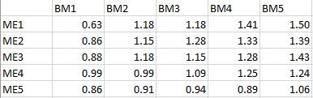

French Website 25 $Size-BM$ Returns

## 6.2 $Size$ and $BM_M$

- Monthly rebalance

```r
df = combine.sources(crsp, comp)
df = df %>% filter(!is.na(L1.ME), !is.na(BMM), BE>0)
```

### 6.2.1 $Size$ Quintiles

```r
quantiles = 1:5/5

nyse = df %>% filter(Exchange=="NYSE") %>% select(Date, PERMNO, L1.ME, BMM)

breakpoints = nyse %>% arrange(Date, L1.ME) %>% group_by(Date) %>% summarize(
    D10=L1.ME[.1*n()], D20=L1.ME[.2*n()],
    D30=L1.ME[.3*n()], D40=L1.ME[.4*n()],
    D50=L1.ME[.5*n()], D60=L1.ME[.6*n()],
    D70=L1.ME[.7*n()], D80=L1.ME[.8*n()],
    D90=L1.ME[.9*n()], D100=L1.ME[n()]) %>% as.data.frame
# breakpoints$Period = breakpoints$Period + 1
breakpoints[, c("PERMNO", "L1.ME")] = NULL
df = left_join(df, breakpoints, by=c("Date"))
df = assign.bkts(df, "L1.ME", quantiles)
```

### 6.2.2 $BM_m$ Quintiles

```r
breakpoints = nyse %>% arrange(Date, BMM) %>% group_by(Date) %>% summarize(
    D10=BMM[.1*n()], D20=BMM[.2*n()],
    D30=BMM[.3*n()], D40=BMM[.4*n()],
    D50=BMM[.5*n()], D60=BMM[.6*n()],
    D70=BMM[.7*n()], D80=BMM[.8*n()],
    D90=BMM[.9*n()], D100=BMM[n()]) %>% as.data.frame
# breakpoints$Period = breakpoints$Period + 1
breakpoints[, c("PERMNO", "BMM")] = NULL
df = left_join(df, breakpoints, by=c("Date"))
df = assign.bkts(df, "BMM", quantiles)
```

```r
df$L1.ME.B = factor(df$L1.ME.B, labels=c("ME1", "ME2", "ME3", "ME4", "ME5"))
df$BMM.B = factor(df$BMM.B, labels=c("BMM1", "BMM2", "BMM3", "BMM4", "BMM5"))
```

```r
# df = ri.adj.Size(df)

df = df %>% group_by(L1.ME.B, BMM.B, Date) %>% mutate(
    bkt.L1.ME=sum(L1.ME, na.rm=TRUE)
) %>% as.data.frame
df$wt.ri = df$ri * df$L1.ME / df$bkt.L1.ME
```

### 6.2.3 Returns

```r
df$L1.ME.BMM.B = interaction(df$L1.ME.B, df$BMM.B)
df$wt.ri = df$wt.ri * 100

returns = df %>% dcast(Date ~ L1.ME.BMM.B, fun.aggregate=sum, value.var="wt.ri", na.rm=TRUE)
colnames(returns)
```

```
##  [1] "Date"     "ME1.BMM1" "ME2.BMM1" "ME3.BMM1" "ME4.BMM1" "ME5.BMM1"
##  [7] "ME1.BMM2" "ME2.BMM2" "ME3.BMM2" "ME4.BMM2" "ME5.BMM2" "ME1.BMM3"
## [13] "ME2.BMM3" "ME3.BMM3" "ME4.BMM3" "ME5.BMM3" "ME1.BMM4" "ME2.BMM4"
## [19] "ME3.BMM4" "ME4.BMM4" "ME5.BMM4" "ME1.BMM5" "ME2.BMM5" "ME3.BMM5"
## [25] "ME4.BMM5" "ME5.BMM5" "NA"
```

```r
write.csv(returns %>% select(-`NA`), "C:/Data/Thesis/25_L1ME_BMM_Returns.csv")
```

## 6.3 $Size$ and $OP$

- Annual rebalance

```r
df = combine.sources(crsp, comp)
df = df %>% filter(!is.na(Size), OP.OK)
```

### 6.3.1 $Size$ Quintiles

```r
quantiles = 1:5/5

nyse = df %>% filter(Exchange=="NYSE", Month==7) %>% select(Period, PERMNO, Size, OP)

breakpoints = nyse %>% arrange(Period, Size) %>% group_by(Period) %>% summarize(
    D10=Size[.1*n()], D20=Size[.2*n()],
    D30=Size[.3*n()], D40=Size[.4*n()],
    D50=Size[.5*n()], D60=Size[.6*n()],
    D70=Size[.7*n()], D80=Size[.8*n()],
    D90=Size[.9*n()], D100=Size[n()]) %>% as.data.frame
breakpoints$Period = breakpoints$Period + 1
breakpoints[, c("PERMNO", "Size")] = NULL
df = left_join(df, breakpoints, by=c("Period"))
df = assign.bkts(df, "Size", quantiles)
```

### 6.3.2 $OP$ Quintiles

```r
breakpoints = nyse %>% arrange(Period, OP) %>% group_by(Period) %>% summarize(
    D10=OP[.1*n()], D20=OP[.2*n()],
    D30=OP[.3*n()], D40=OP[.4*n()],
    D50=OP[.5*n()], D60=OP[.6*n()],
    D70=OP[.7*n()], D80=OP[.8*n()],
    D90=OP[.9*n()], D100=OP[n()]) %>% as.data.frame
breakpoints$Period = breakpoints$Period + 1
breakpoints[, c("PERMNO", "OP")] = NULL
df = left_join(df, breakpoints, by=c("Period"))
df = assign.bkts(df, "OP", quantiles)
```

```r
df %>% group_by(Size.B, OP.B, Date) %>% summarize(N=n()) %>% group_by(Size.B, OP.B) %>%
    dcast(Size.B ~ OP.B, value.var="N", fun.aggregate=mean, na.rm=TRUE) %>%
    round(0)
```

| Size.B | 1 | 2 | 3 | 4 | 5 | NA |
| --- | --- | --- | --- | --- | --- | --- |
| 1 | 1053 | 338 | 297 | 236 | 254 | 3 |
| 2 | 149 | 110 | 113 | 106 | 101 | 1 |
| 3 | 78 | 75 | 86 | 87 | 85 | 1 |
| 4 | 51 | 61 | 69 | 77 | 78 | 1 |
| 5 | 36 | 51 | 57 | 75 | 90 | 1 |
| NA | NaN | 1 | 1 | 1 | 1 | 516 |

```r
# df = ri.adj.Size(df)

df = df %>% group_by(Size.B, OP.B, Date) %>% mutate(
    adj.bkt.Size=sum(adj.Size, na.rm=TRUE)
) %>% as.data.frame
df$wt.ri = df$ri * df$adj.Size / df$adj.bkt.Size
```

### 6.3.3 Returns

```r
df$Size.OP.B = interaction(df$Size.B, df$OP.B)
df$wt.ri = df$wt.ri * 100

returns = df %>% dcast(Date ~ Size.OP.B, fun.aggregate=sum, value.var="wt.ri", na.rm=TRUE)
write.csv(returns, "C:/Data/Thesis/25_Size_OP_Returns.csv")

df %>% group_by(Size.B, OP.B, Date) %>% summarise(rp=sum(wt.ri, na.rm=TRUE)) %>%
    dcast(Size.B ~ OP.B, fun.aggregate=mean, value.var="rp", na.rm=TRUE) %>%
    select(-`NA`) %>% filter(!is.na(Size.B)) %>% round(digits=2)
```

| Size.B | 1 | 2 | 3 | 4 | 5 |
| --- | --- | --- | --- | --- | --- |
| 1 | 0.95 | 1.32 | 1.33 | 1.26 | 1.32 |
| 2 | 0.91 | 1.20 | 1.20 | 1.23 | 1.33 |
| 3 | 0.94 | 1.16 | 1.10 | 1.10 | 1.26 |
| 4 | 0.90 | 1.00 | 1.09 | 1.12 | 1.18 |
| 5 | 0.75 | 0.80 | 0.85 | 0.92 | 0.94 |

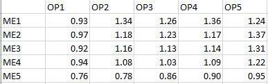

French Website 25 $Size-OP$ Returns

## 6.4 $Size$ and $GP$

- Annual rebalance

```r
df = combine.sources(crsp, comp)
df = df %>% filter(!is.na(Size), !is.na(GP))
```

### 6.4.1 $Size$ Quintiles

```r
quantiles = 1:5/5

nyse = df %>% filter(Exchange=="NYSE", Month==7) %>% select(Period, PERMNO, Size, GP)

breakpoints = nyse %>% arrange(Period, Size) %>% group_by(Period) %>% summarize(
    D10=Size[.1*n()], D20=Size[.2*n()],
    D30=Size[.3*n()], D40=Size[.4*n()],
    D50=Size[.5*n()], D60=Size[.6*n()],
    D70=Size[.7*n()], D80=Size[.8*n()],
    D90=Size[.9*n()], D100=Size[n()]) %>% as.data.frame
breakpoints$Period = breakpoints$Period + 1
breakpoints[, c("PERMNO", "Size")] = NULL
df = left_join(df, breakpoints, by=c("Period"))
df = assign.bkts(df, "Size", quantiles)
```

### 6.4.2 $GP$ Quintiles

```r
breakpoints = nyse %>% arrange(Period, GP) %>% group_by(Period) %>% summarize(
    D10=GP[.1*n()], D20=GP[.2*n()],
    D30=GP[.3*n()], D40=GP[.4*n()],
    D50=GP[.5*n()], D60=GP[.6*n()],
    D70=GP[.7*n()], D80=GP[.8*n()],
    D90=GP[.9*n()], D100=GP[n()]) %>% as.data.frame
breakpoints$Period = breakpoints$Period + 1
breakpoints[, c("PERMNO", "GP")] = NULL
df = left_join(df, breakpoints, by=c("Period"))
df = assign.bkts(df, "GP", quantiles)
```

```r
df$Size.B = factor(df$Size.B, labels=c("ME1", "ME2", "ME3", "ME4", "ME5"))
df$GP.B = factor(df$GP.B, labels=c("GP1", "GP2", "GP3", "GP4", "GP5"))
```

```r
# df = ri.adj.Size(df)

df = df %>% group_by(Size.B, GP.B, Date) %>% mutate(
    adj.bkt.Size=sum(adj.Size, na.rm=TRUE)
) %>% as.data.frame
df$wt.ri = df$ri * df$adj.Size / df$adj.bkt.Size
```

### 6.4.3 Returns

```r
df$Size.GP.B = interaction(df$Size.B, df$GP.B)
df$wt.ri = df$wt.ri * 100

returns = df %>% dcast(Date ~ Size.GP.B, fun.aggregate=sum, value.var="wt.ri", na.rm=TRUE)
write.csv(returns %>% select(-`NA`), "C:/Data/Thesis/25_Size_GP_Returns.csv")
```

## 6.5 $Size$ and $CP$

- Annual rebalance

```r
df = combine.sources(crsp, comp)
df = df %>% filter(!is.na(Size), OP.OK)
```

### 6.5.1 $Size$ Quintiles

```r
quantiles = 1:5/5

nyse = df %>% filter(Exchange=="NYSE", Month==7) %>% select(Period, PERMNO, Size, CP)

breakpoints = nyse %>% arrange(Period, Size) %>% group_by(Period) %>% summarize(
    D10=Size[.1*n()], D20=Size[.2*n()],
    D30=Size[.3*n()], D40=Size[.4*n()],
    D50=Size[.5*n()], D60=Size[.6*n()],
    D70=Size[.7*n()], D80=Size[.8*n()],
    D90=Size[.9*n()], D100=Size[n()]) %>% as.data.frame
breakpoints$Period = breakpoints$Period + 1
breakpoints[, c("PERMNO", "Size")] = NULL
df = left_join(df, breakpoints, by=c("Period"))
df = assign.bkts(df, "Size", quantiles)
```

### 6.5.2 $CP$ Quintiles

```r
breakpoints = nyse %>% arrange(Period, CP) %>% group_by(Period) %>% summarize(
    D10=CP[.1*n()], D20=CP[.2*n()],
    D30=CP[.3*n()], D40=CP[.4*n()],
    D50=CP[.5*n()], D60=CP[.6*n()],
    D70=CP[.7*n()], D80=CP[.8*n()],
    D90=CP[.9*n()], D100=CP[n()]) %>% as.data.frame
breakpoints$Period = breakpoints$Period + 1
breakpoints[, c("PERMNO", "CP")] = NULL
df = left_join(df, breakpoints, by=c("Period"))
df = assign.bkts(df, "CP", quantiles)
```

```r
df$Size.B = factor(df$Size.B, labels=c("ME1", "ME2", "ME3", "ME4", "ME5"))
df$CP.B = factor(df$CP.B, labels=c("CP1", "CP2", "CP3", "CP4", "CP5"))
```

```r
# df = ri.adj.Size(df)

df = df %>% group_by(Size.B, CP.B, Date) %>% mutate(
    adj.bkt.Size=sum(adj.Size, na.rm=TRUE)
) %>% as.data.frame
df$wt.ri = df$ri * df$adj.Size / df$adj.bkt.Size
```

### 6.5.3 Returns

```r
df$Size.CP.B = interaction(df$Size.B, df$CP.B)
df$wt.ri = df$wt.ri * 100

returns = df %>% dcast(Date ~ Size.CP.B, fun.aggregate=sum, value.var="wt.ri", na.rm=TRUE)
write.csv(returns %>% select(-`NA`), "C:/Data/Thesis/25_Size_CP_Returns.csv")
```

## 6.6 $Size$ and $INV$

- Annual rebalance

```r
df = combine.sources(crsp, comp)
df = df %>% filter(!is.na(Size), !is.na(INV))
```

### 6.6.1 $Size$ Quintiles

```r
quantiles = 1:5/5

nyse = df %>% filter(Exchange=="NYSE", Month==7) %>% select(Period, PERMNO, Size, INV)

breakpoints = nyse %>% arrange(Period, Size) %>% group_by(Period) %>% summarize(
    D10=Size[.1*n()], D20=Size[.2*n()],
    D30=Size[.3*n()], D40=Size[.4*n()],
    D50=Size[.5*n()], D60=Size[.6*n()],
    D70=Size[.7*n()], D80=Size[.8*n()],
    D90=Size[.9*n()], D100=Size[n()]) %>% as.data.frame
breakpoints$Period = breakpoints$Period + 1
breakpoints[, c("PERMNO", "Size")] = NULL
df = left_join(df, breakpoints, by=c("Period"))
df = assign.bkts(df, "Size", quantiles)
```

### 6.6.2 $INV$ Quintiles

```r
breakpoints = nyse %>% arrange(Period, INV) %>% group_by(Period) %>% summarize(
    D10=INV[.1*n()], D20=INV[.2*n()],
    D30=INV[.3*n()], D40=INV[.4*n()],
    D50=INV[.5*n()], D60=INV[.6*n()],
    D70=INV[.7*n()], D80=INV[.8*n()],
    D90=INV[.9*n()], D100=INV[n()]) %>% as.data.frame
breakpoints$Period = breakpoints$Period + 1
breakpoints[, c("PERMNO", "INV")] = NULL
df = left_join(df, breakpoints, by=c("Period"))
df = assign.bkts(df, "INV", quantiles)
```

```r
df %>% group_by(Size.B, INV.B, Date) %>% summarize(N=n()) %>% group_by(Size.B, INV.B) %>%
    dcast(Size.B ~ INV.B, value.var="N", fun.aggregate=mean, na.rm=TRUE) %>%
    round(0)
```

| Size.B | 1 | 2 | 3 | 4 | 5 | NA |
| --- | --- | --- | --- | --- | --- | --- |
| 1 | 674 | 296 | 263 | 283 | 470 | 8 |
| 2 | 104 | 89 | 91 | 108 | 172 | 3 |
| 3 | 59 | 65 | 74 | 84 | 120 | 2 |
| 4 | 45 | 60 | 66 | 74 | 87 | 2 |
| 5 | 35 | 59 | 70 | 74 | 68 | 2 |
| NA | 1 | 1 | 1 | 1 | 1 | 541 |

```r
# df = ri.adj.Size(df)

df = df %>% group_by(Size.B, INV.B, Date) %>% mutate(
    adj.bkt.Size=sum(adj.Size, na.rm=TRUE)
) %>% as.data.frame
df$wt.ri = df$ri * df$adj.Size / df$adj.bkt.Size
```

### 6.6.3 Returns

```r
df$Size.INV.B = interaction(df$Size.B, df$INV.B)
df$wt.ri = df$wt.ri * 100

returns = df %>% dcast(Date ~ Size.INV.B, fun.aggregate=sum, value.var="wt.ri", na.rm=TRUE)
write.csv(returns, "C:/Data/Thesis/25_Size_INV_Returns.csv")

df %>% group_by(Size.B, INV.B, Date) %>% summarise(rp=sum(wt.ri, na.rm=TRUE)) %>%
    dcast(Size.B ~ INV.B, fun.aggregate=mean, value.var="rp", na.rm=TRUE) %>%
    select(-`NA`) %>% filter(!is.na(Size.B)) %>% round(digits=2)
```

| Size.B | 1 | 2 | 3 | 4 | 5 |
| --- | --- | --- | --- | --- | --- |
| 1 | 1.31 | 1.38 | 1.39 | 1.25 | 0.83 |
| 2 | 1.30 | 1.35 | 1.27 | 1.30 | 0.91 |
| 3 | 1.25 | 1.20 | 1.29 | 1.15 | 0.91 |
| 4 | 1.04 | 1.21 | 1.08 | 1.13 | 0.94 |
| 5 | 1.07 | 0.96 | 0.91 | 0.81 | 0.83 |

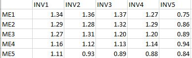

French Website 25 $Size-INV$ Returns

### 6.6.4 $BM$

```r
df %>% group_by(Size.B, INV.B, Date) %>% summarise(avg.BM=mean(BM, na.rm=TRUE)) %>%
    dcast(Size.B ~ INV.B, fun.aggregate=mean, value.var="avg.BM", na.rm=TRUE) %>%
    select(-`NA`) %>% filter(!is.na(Size.B)) %>% round(digits=2)
```

| Size.B | 1 | 2 | 3 | 4 | 5 |
| --- | --- | --- | --- | --- | --- |
| 1 | 1.09 | 1.25 | 1.14 | 1.04 | 0.77 |
| 2 | 0.93 | 0.93 | 0.87 | 0.76 | 0.59 |
| 3 | 0.87 | 0.86 | 0.78 | 0.68 | 0.52 |
| 4 | 0.83 | 0.81 | 0.72 | 0.62 | 0.50 |
| 5 | 0.77 | 0.78 | 0.65 | 0.56 | 0.45 |

### 6.6.5 $BM_M$

```r
df %>% group_by(Size.B, INV.B, Date) %>% summarise(avg.BMM=mean(BMM, na.rm=TRUE)) %>%
    dcast(Size.B ~ INV.B, fun.aggregate=mean, value.var="avg.BMM", na.rm=TRUE) %>%
    select(-`NA`) %>% filter(!is.na(Size.B)) %>% round(digits=2)
```

| Size.B | 1 | 2 | 3 | 4 | 5 |
| --- | --- | --- | --- | --- | --- |
| 1 | 1.13 | 1.27 | 1.14 | 1.06 | 0.91 |
| 2 | 0.92 | 0.89 | 0.84 | 0.73 | 0.59 |
| 3 | 0.80 | 0.82 | 0.74 | 0.64 | 0.51 |
| 4 | 0.79 | 0.78 | 0.69 | 0.59 | 0.48 |
| 5 | 0.72 | 0.74 | 0.63 | 0.54 | 0.43 |

### 6.6.6 $OP$

```r
df[df$OP.OK, ] %>% group_by(Size.B, INV.B, Date) %>% summarise(avg.OP=mean(OP, na.rm=TRUE)) %>%
    dcast(Size.B ~ INV.B, fun.aggregate=mean, value.var="avg.OP", na.rm=TRUE) %>%
    select(-`NA`) %>% filter(!is.na(Size.B)) %>% round(digits=2)
```

| Size.B | 1 | 2 | 3 | 4 | 5 |
| --- | --- | --- | --- | --- | --- |
| 1 | -0.18 | 0.13 | 0.20 | 0.21 | 0.13 |
| 2 | 0.25 | 0.24 | 0.25 | 0.27 | 0.25 |
| 3 | 0.21 | 0.27 | 0.31 | 0.32 | 0.31 |
| 4 | 0.28 | 0.31 | 0.31 | 0.34 | 0.33 |
| 5 | 0.37 | 0.36 | 0.36 | 0.35 | 0.36 |

### 6.6.7 $GP$

```r
df %>% group_by(Size.B, INV.B, Date) %>% summarise(avg.GP=mean(GP, na.rm=TRUE)) %>%
    dcast(Size.B ~ INV.B, fun.aggregate=mean, value.var="avg.GP", na.rm=TRUE) %>%
    select(-`NA`) %>% filter(!is.na(Size.B)) %>% round(digits=2)
```

| Size.B | 1 | 2 | 3 | 4 | 5 |
| --- | --- | --- | --- | --- | --- |
| 1 | 0.31 | 0.36 | 0.36 | 0.38 | 0.34 |
| 2 | 0.30 | 0.31 | 0.33 | 0.37 | 0.36 |
| 3 | 0.30 | 0.29 | 0.32 | 0.35 | 0.36 |
| 4 | 0.29 | 0.28 | 0.31 | 0.34 | 0.35 |
| 5 | 0.30 | 0.28 | 0.31 | 0.34 | 0.36 |

### 6.6.8 $CP$

```r
df[df$OP.OK, ] %>% group_by(Size.B, INV.B, Date) %>% summarise(avg.CP=mean(CP, na.rm=TRUE)) %>%
    dcast(Size.B ~ INV.B, fun.aggregate=mean, value.var="avg.CP", na.rm=TRUE) %>%
    select(-`NA`) %>% filter(!is.na(Size.B)) %>% round(digits=2)
```

| Size.B | 1 | 2 | 3 | 4 | 5 |
| --- | --- | --- | --- | --- | --- |
| 1 | 0.43 | 0.19 | 0.22 | 0.21 | 0.09 |
| 2 | 0.36 | 0.30 | 0.27 | 0.30 | 0.24 |
| 3 | 0.07 | 0.30 | 0.32 | 0.33 | 0.30 |
| 4 | 0.43 | 0.33 | 0.31 | 0.34 | 0.33 |
| 5 | 0.51 | 0.39 | 0.38 | 0.33 | 0.33 |

### 6.6.9 $Acc$

```r
df %>% group_by(Size.B, INV.B, Date) %>% summarise(avg.Acc=mean(Acc, na.rm=TRUE)) %>%
    dcast(Size.B ~ INV.B, fun.aggregate=mean, value.var="avg.Acc", na.rm=TRUE) %>%
    select(-`NA`) %>% filter(!is.na(Size.B)) %>% round(digits=2)
```

| Size.B | 1 | 2 | 3 | 4 | 5 |
| --- | --- | --- | --- | --- | --- |
| 1 | -0.15 | -0.02 | 0.09 | 0.06 | 0.24 |
| 2 | -0.01 | -0.02 | 0.03 | 0.07 | 0.17 |
| 3 | -0.31 | -0.02 | 0.04 | 0.07 | 0.17 |
| 4 | -0.09 | 0.01 | 0.02 | 0.04 | 0.12 |
| 5 | -0.02 | 0.00 | 0.00 | 0.05 | 0.12 |

## 6.7 $Size$ and $Prior$

- Monthly rebalance

```r
df = combine.sources(crsp, comp)
df = df %>% filter(!is.na(L1.ME), !is.na(Prior), !is.na(L13.price), !is.na(L1.ri))
```

### 6.7.1 $Size$ Quintiles

```r
quantiles = 1:5/5

nyse = df %>% filter(Exchange=="NYSE") %>% select(Date, PERMNO, L1.ME, Prior)

breakpoints = nyse %>% arrange(Date, L1.ME) %>% group_by(Date) %>% summarize(
    D10=L1.ME[.1*n()], D20=L1.ME[.2*n()],
    D30=L1.ME[.3*n()], D40=L1.ME[.4*n()],
    D50=L1.ME[.5*n()], D60=L1.ME[.6*n()],
    D70=L1.ME[.7*n()], D80=L1.ME[.8*n()],
    D90=L1.ME[.9*n()], D100=L1.ME[n()]) %>% as.data.frame
# breakpoints$Period = breakpoints$Period + 1
breakpoints[, c("PERMNO", "L1.ME")] = NULL
df = left_join(df, breakpoints, by=c("Date"))
df = assign.bkts(df, "L1.ME", quantiles)
```

### 6.7.2 $Prior$ Quintiles

```r
breakpoints = nyse %>% arrange(Date, Prior) %>% group_by(Date) %>% summarize(
    D10=Prior[.1*n()], D20=Prior[.2*n()],
    D30=Prior[.3*n()], D40=Prior[.4*n()],
    D50=Prior[.5*n()], D60=Prior[.6*n()],
    D70=Prior[.7*n()], D80=Prior[.8*n()],
    D90=Prior[.9*n()], D100=Prior[n()]) %>% as.data.frame
# breakpoints$Period = breakpoints$Period + 1
breakpoints[, c("PERMNO", "Prior")] = NULL
df = left_join(df, breakpoints, by=c("Date"))
df = assign.bkts(df, "Prior", quantiles)
```

```r
df %>% group_by(L1.ME.B, Prior.B, Date) %>% summarize(N=n()) %>% group_by(L1.ME.B, Prior.B) %>%
    dcast(L1.ME.B ~ Prior.B, value.var="N", fun.aggregate=mean, na.rm=TRUE) %>%
    round(0)
```

| L1.ME.B | 1 | 2 | 3 | 4 | 5 | NA |
| --- | --- | --- | --- | --- | --- | --- |
| 1 | 828 | 385 | 314 | 328 | 602 | 20 |
| 2 | 120 | 110 | 106 | 114 | 176 | 3 |
| 3 | 67 | 80 | 83 | 87 | 114 | 2 |
| 4 | 49 | 68 | 74 | 77 | 80 | 2 |
| 5 | 38 | 63 | 73 | 73 | 59 | 3 |
| NA | 1 | 1 | 1 | 1 | 1 | NaN |

```r
# df = ri.adj.Size(df)

df = df %>% group_by(L1.ME.B, Prior.B, Date) %>% mutate(
    bkt.L1.ME=sum(L1.ME, na.rm=TRUE)
) %>% as.data.frame
df$wt.ri = df$ri * df$L1.ME / df$bkt.L1.ME
```

### 6.7.3 Returns

```r
df$L1.ME.Prior.B = interaction(df$L1.ME.B, df$Prior.B)
df$wt.ri = df$wt.ri * 100

returns = df %>% dcast(Date ~ L1.ME.Prior.B, fun.aggregate=sum, value.var="wt.ri", na.rm=TRUE)
write.csv(returns, "C:/Data/Thesis/25_L1ME_Prior_Returns.csv")

df %>% group_by(L1.ME.B, Prior.B, Date) %>% summarise(rp=sum(wt.ri, na.rm=TRUE)) %>%
    dcast(L1.ME.B ~ Prior.B, fun.aggregate=mean, value.var="rp", na.rm=TRUE) %>%
    select(-`NA`) %>% filter(!is.na(L1.ME.B)) %>% round(digits=2)
```

| L1.ME.B | 1 | 2 | 3 | 4 | 5 |
| --- | --- | --- | --- | --- | --- |
| 1 | 0.48 | 1.04 | 1.27 | 1.42 | 1.65 |
| 2 | 0.63 | 1.03 | 1.25 | 1.35 | 1.59 |
| 3 | 0.73 | 1.02 | 1.11 | 1.15 | 1.52 |
| 4 | 0.73 | 0.97 | 1.06 | 1.18 | 1.39 |
| 5 | 0.68 | 0.88 | 0.78 | 1.00 | 1.21 |

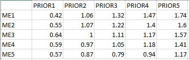

French Website 25 $ME-Prior$ Returns

## 6.8 Value and Momentum

- Monthly rebalance

```r
df = combine.sources(crsp, comp)
df = df %>% filter(!is.na(L1.ME), !is.na(Prior), !is.na(L13.price), !is.na(L1.ri),
                   !is.infinite(CP))
```

### 6.8.1 Value Quintiles

```r
quantiles = 1:5/5

nyse = df %>% filter(Exchange=="NYSE") %>% select(Date, PERMNO, BMM, Prior)

breakpoints = nyse %>% arrange(Date, BMM) %>% group_by(Date) %>% summarize(
    D10=BMM[.1*n()], D20=BMM[.2*n()],
    D30=BMM[.3*n()], D40=BMM[.4*n()],
    D50=BMM[.5*n()], D60=BMM[.6*n()],
    D70=BMM[.7*n()], D80=BMM[.8*n()],
    D90=BMM[.9*n()], D100=BMM[n()]) %>% as.data.frame
# breakpoints$Period = breakpoints$Period + 1
breakpoints[, c("PERMNO", "BMM")] = NULL
df = left_join(df, breakpoints, by=c("Date"))
df = assign.bkts(df, "BMM", quantiles)
```

### 6.8.2 $Prior$ Quintiles

```r
breakpoints = nyse %>% arrange(Date, Prior) %>% group_by(Date) %>% summarize(
    D10=Prior[.1*n()], D20=Prior[.2*n()],
    D30=Prior[.3*n()], D40=Prior[.4*n()],
    D50=Prior[.5*n()], D60=Prior[.6*n()],
    D70=Prior[.7*n()], D80=Prior[.8*n()],
    D90=Prior[.9*n()], D100=Prior[n()]) %>% as.data.frame
# breakpoints$Period = breakpoints$Period + 1
breakpoints[, c("PERMNO", "Prior")] = NULL
df = left_join(df, breakpoints, by=c("Date"))
df = assign.bkts(df, "Prior", quantiles)
```

### 6.8.3 ME

```r
df %>% group_by(BMM.B, Prior.B, Date) %>% summarise(Avg.ME=mean(ME, na.rm=TRUE)) %>%
    dcast(BMM.B ~ Prior.B, fun.aggregate=mean, value.var="Avg.ME", na.rm=TRUE) %>%
    select(-`NA`) %>% filter(!is.na(BMM.B)) %>% round(2)
```

| BMM.B | 1 | 2 | 3 | 4 | 5 |
| --- | --- | --- | --- | --- | --- |
| 1 | 1436.27 | 3466.80 | 4146.99 | 3858.76 | 1880.67 |
| 2 | 1336.60 | 2892.78 | 3264.48 | 2848.84 | 1263.80 |
| 3 | 900.91 | 1909.73 | 2179.94 | 1986.00 | 982.28 |
| 4 | 705.60 | 1325.19 | 1550.62 | 1399.65 | 766.84 |
| 5 | 1260.40 | 1830.79 | 4722.79 | 5712.31 | 3763.93 |

### 6.8.4 Investment

```r
df %>% group_by(BMM.B, Prior.B, Date) %>% summarise(Avg.INV=mean(INV, na.rm=TRUE)) %>%
    dcast(BMM.B ~ Prior.B, fun.aggregate=mean, value.var="Avg.INV", na.rm=TRUE) %>%
    select(-`NA`) %>% filter(!is.na(BMM.B)) %>% round(2)
```

| BMM.B | 1 | 2 | 3 | 4 | 5 |
| --- | --- | --- | --- | --- | --- |
| 1 | 0.30 | 0.26 | 0.25 | 0.25 | 0.26 |
| 2 | 0.32 | 0.23 | 0.18 | 0.17 | 0.16 |
| 3 | 0.25 | 0.17 | 0.13 | 0.12 | 0.10 |
| 4 | 0.22 | 0.13 | 0.11 | 0.09 | 0.08 |
| 5 | 0.12 | 0.07 | 0.09 | 0.04 | 0.02 |

### 6.8.5 CP

```r
df %>% group_by(BMM.B, Prior.B, Date) %>% summarise(Avg.CP=mean(CP, na.rm=TRUE)) %>%
    dcast(BMM.B ~ Prior.B, fun.aggregate=mean, value.var="Avg.CP", na.rm=TRUE) %>%
    select(-`NA`) %>% filter(!is.na(BMM.B)) %>% round(2)
```

| BMM.B | 1 | 2 | 3 | 4 | 5 |
| --- | --- | --- | --- | --- | --- |
| 1 | 0.21 | 0.41 | 0.13 | -0.12 | 0.65 |
| 2 | 0.20 | 0.28 | 0.30 | 0.28 | 0.23 |
| 3 | 0.20 | 0.25 | 0.24 | 0.23 | 0.21 |
| 4 | 0.20 | 0.21 | 0.20 | 0.20 | 0.17 |
| 5 | 0.10 | 0.22 | 0.21 | 0.14 | 0.18 |

### 6.8.6 Accruals

```r
df %>% group_by(BMM.B, Prior.B, Date) %>% summarise(Avg.Acc=mean(Acc, na.rm=TRUE)) %>%
    dcast(BMM.B ~ Prior.B, fun.aggregate=mean, value.var="Avg.Acc", na.rm=TRUE) %>%
    select(-`NA`) %>% filter(!is.na(BMM.B)) %>% round(4)
```

| BMM.B | 1 | 2 | 3 | 4 | 5 |
| --- | --- | --- | --- | --- | --- |
| 1 | 0.1552 | 0.1101 | 0.2349 | 0.0908 | 0.0861 |
| 2 | 0.0333 | 0.0424 | 0.0328 | 0.0318 | 0.0162 |
| 3 | 0.0475 | 0.0329 | 0.0247 | 0.0196 | 0.0015 |
| 4 | 0.0263 | 0.0142 | 0.0080 | 0.0004 | -0.0178 |
| 5 | -0.0014 | 0.0158 | 0.0178 | 0.0009 | 0.0109 |

## 6.9 $Acc$ and $INV$

- Annual rebalance

```r
df = combine.sources(crsp, comp)
df = df %>% filter(!is.na(Acc), !is.na(INV))
```

### 6.9.1 $Acc$ Quintiles

```r
quantiles = 1:5/5

nyse = df %>% filter(Exchange=="NYSE", Month==7) %>% select(Period, PERMNO, Acc, INV)

breakpoints = nyse %>% arrange(Period, Acc) %>% group_by(Period) %>% summarize(
    D10=Acc[.1*n()], D20=Acc[.2*n()],
    D30=Acc[.3*n()], D40=Acc[.4*n()],
    D50=Acc[.5*n()], D60=Acc[.6*n()],
    D70=Acc[.7*n()], D80=Acc[.8*n()],
    D90=Acc[.9*n()], D100=Acc[n()]) %>% as.data.frame
breakpoints$Period = breakpoints$Period + 1
breakpoints[, c("PERMNO", "Acc")] = NULL
df = left_join(df, breakpoints, by=c("Period"))
df = assign.bkts(df, "Acc", quantiles)
```

### 6.9.2 $INV$ Quintiles

```r
breakpoints = nyse %>% arrange(Period, INV) %>% group_by(Period) %>% summarize(
    D10=INV[.1*n()], D20=INV[.2*n()],
    D30=INV[.3*n()], D40=INV[.4*n()],
    D50=INV[.5*n()], D60=INV[.6*n()],
    D70=INV[.7*n()], D80=INV[.8*n()],
    D90=INV[.9*n()], D100=INV[n()]) %>% as.data.frame
breakpoints$Period = breakpoints$Period + 1
breakpoints[, c("PERMNO", "INV")] = NULL
df = left_join(df, breakpoints, by=c("Period"))
df = assign.bkts(df, "INV", quantiles)
```

```r
df %>% group_by(Acc.B, INV.B, Date) %>% summarize(N=n()) %>% group_by(Acc.B, INV.B) %>%
    dcast(Acc.B ~ INV.B, value.var="N", fun.aggregate=mean, na.rm=TRUE) %>%
    round(0)
```

| Acc.B | 1 | 2 | 3 | 4 | 5 | NA |
| --- | --- | --- | --- | --- | --- | --- |
| 1 | 417 | 107 | 74 | 72 | 119 | 4 |
| 2 | 124 | 111 | 88 | 77 | 79 | 3 |
| 3 | 80 | 100 | 99 | 89 | 79 | 3 |
| 4 | 76 | 84 | 108 | 131 | 135 | 3 |
| 5 | 129 | 66 | 82 | 146 | 408 | 9 |
| NA | 4 | 1 | 2 | 2 | 2 | 48 |

```r
# df = ri.adj.Size(df)

df = df %>% group_by(Acc.B, INV.B, Date) %>% mutate(
    adj.bkt.Size=sum(adj.Size, na.rm=TRUE)
) %>% as.data.frame
df$wt.ri = df$ri * df$adj.Size / df$adj.bkt.Size
```

### 6.9.3 Returns

```r
df$Acc.INV.B = interaction(df$Acc.B, df$INV.B)
df$wt.ri = df$wt.ri * 100

returns = df %>% dcast(Date ~ Acc.INV.B, fun.aggregate=sum, value.var="wt.ri", na.rm=TRUE)
write.csv(returns, "C:/Data/Thesis/25_Acc_INV_Returns.csv")

df %>% group_by(Acc.B, INV.B, Date) %>% summarise(rp=sum(wt.ri, na.rm=TRUE)) %>%
    dcast(Acc.B ~ INV.B, fun.aggregate=mean, value.var="rp", na.rm=TRUE) %>%
    select(-`NA`) %>% filter(!is.na(Acc.B)) %>% round(digits=2)
```

| Acc.B | 1 | 2 | 3 | 4 | 5 |
| --- | --- | --- | --- | --- | --- |
| 1 | 1.30 | 1.00 | 1.04 | 1.06 | 0.91 |
| 2 | 1.08 | 1.02 | 0.86 | 0.95 | 1.07 |
| 3 | 1.03 | 1.08 | 0.94 | 0.89 | 0.78 |
| 4 | 0.88 | 1.13 | 0.93 | 0.89 | 0.76 |
| 5 | 1.13 | 1.22 | 1.26 | 0.97 | 0.86 |

# 7 Create Factors

## 7.1 Market Excess Return, $R_M$

```r
rm = crsp %>% select(Date, rmkt) %>% filter(!duplicated(c(Date)))

rm$rmkt = rm$rmkt * 100
summary(rm)
```

```
##       Date                 rmkt
##  Min.   :1960-01-29   Min.   :-22.5363
##  1st Qu.:1974-04-22   1st Qu.: -1.7139
##  Median :1988-07-14   Median :  1.2109
##  Mean   :1988-07-15   Mean   :  0.8754
##  3rd Qu.:2002-10-07   3rd Qu.:  3.7938
##  Max.   :2016-12-30   Max.   : 16.5585
```

```r
rf = fread("C:/Data/CRSP/RF_196307_201612.csv")
```

```r
rf$Date = as.Date(as.character(rf$caldt), "%Y%m%d")
rf$caldt = NULL
rf$rf = rf$t30ret * 100
rf$t30ret = NULL
summary(rf)
```

```
##       Date                  rf
##  Min.   :1963-07-31   Min.   :-0.0037
##  1st Qu.:1976-12-07   1st Qu.: 0.2360
##  Median :1990-04-14   Median : 0.3924
##  Mean   :1990-04-15   Mean   : 0.3920
##  3rd Qu.:2003-08-21   3rd Qu.: 0.5245
##  Max.   :2016-12-30   Max.   : 1.5158
```

```r
rm = left_join(rm, rf, by=c("Date"))
```

```r
rm$rf[is.na(rm$rf)] = mean(rm$rf, na.rm=TRUE)
rm$rmkt[is.na(rm$rmkt)] = mean(rm$rmkt, na.rm=TRUE)
rm$Rm = rm$rmkt - rm$rf
rm = rm %>% filter(Date>as.Date("1963-06-30"))
summary(rm)
```

```
##       Date                 rmkt                rf
##  Min.   :1963-07-31   Min.   :-22.5363   Min.   :-0.0037
##  1st Qu.:1976-12-07   1st Qu.: -1.6861   1st Qu.: 0.2360
##  Median :1990-04-14   Median :  1.1947   Median : 0.3921
##  Mean   :1990-04-15   Mean   :  0.8877   Mean   : 0.3919
##  3rd Qu.:2003-08-21   3rd Qu.:  3.8163   3rd Qu.: 0.5245
##  Max.   :2016-12-30   Max.   : 16.5585   Max.   : 1.5158
##        Rm
##  Min.   :-23.1403
##  1st Qu.: -2.1159
##  Median :  0.8472
##  Mean   :  0.4959
##  3rd Qu.:  3.4806
##  Max.   : 16.0331
```

```r
rbind(sapply(rm[,-1], mean), sapply(rm[,-1], se), sapply(rm[,-1], t.stat)) %>% round(2)
```

```
##      rmkt    rf   Rm
## [1,] 0.89  0.39 0.50
## [2,] 0.17  0.01 0.17
## [3,] 5.11 37.13 2.84
```

```r
rm$rmkt = NULL
rm$rf = NULL
```

## 7.2 $Size$ and $BM$

- Annual rebalance

```r
df = combine.sources(crsp, comp)
df = df %>% filter(!is.na(BM), !is.na(Size), BE>0)
```

```r
df %>% select(Date, PERMNO, Size, BM) %>% arrange(Date) %>% head
```

|  | Date | PERMNO | Size | BM |
| --- | --- | --- | --- | --- |
| 1 | 1962-07-31 | 10006 | 84.1930 | 1.2828831 |
| 2 | 1962-07-31 | 10014 | 11.2770 | 0.8882029 |
| 3 | 1962-07-31 | 10102 | 217.9530 | 0.5732686 |
| 4 | 1962-07-31 | 10137 | 393.0705 | 0.4435748 |
| 5 | 1962-07-31 | 10153 | 137.6526 | 1.7926768 |
| 6 | 1962-07-31 | 10161 | 417.7193 | 0.4312827 |

### 7.2.1 $Size$ Median

```r
quantiles = 1:2/2

nyse = df %>% filter(Exchange=="NYSE", Month==7) %>% select(Period, PERMNO, Size, BM)

breakpoints = nyse %>% arrange(Period, Size) %>% group_by(Period) %>% summarize(
    D10=Size[.1*n()], D20=Size[.2*n()],
    D30=Size[.3*n()], D40=Size[.4*n()],
    D50=Size[.5*n()], D60=Size[.6*n()],
    D70=Size[.7*n()], D80=Size[.8*n()],
    D90=Size[.9*n()], D100=Size[n()]) %>% as.data.frame
breakpoints$Period = breakpoints$Period + 1
breakpoints[, c("PERMNO", "Size")] = NULL
df = left_join(df, breakpoints, by=c("Period"))
df = assign.bkts(df, "Size", quantiles)
```

### 7.2.2 $BM$ Quantiles

```r
quantiles = c(.3, .7, 1.)

breakpoints = nyse %>% arrange(Period, BM) %>% group_by(Period) %>% summarize(
    D10=BM[.1*n()], D20=BM[.2*n()],
    D30=BM[.3*n()], D40=BM[.4*n()],
    D50=BM[.5*n()], D60=BM[.6*n()],
    D70=BM[.7*n()], D80=BM[.8*n()],
    D90=BM[.9*n()], D100=BM[n()]) %>% as.data.frame
breakpoints$Period = breakpoints$Period + 1
breakpoints[, c("PERMNO", "BM")] = NULL
df = left_join(df, breakpoints, by=c("Period"))
df = assign.bkts(df, "BM", quantiles)
```

```r
summary(df %>% select(Size.B, BM.B))
```

```
##      Size.B           BM.B
##  Min.   :1.000   Min.   :1.000
##  1st Qu.:1.000   1st Qu.:1.000
##  Median :1.000   Median :2.000
##  Mean   :1.219   Mean   :1.959
##  3rd Qu.:1.000   3rd Qu.:3.000
##  Max.   :2.000   Max.   :3.000
##  NA's   :6918    NA's   :7923
```

```r
typeof(df$Size.B)
```

```
## [1] "double"
```

```r
df$Size.B = factor(df$Size.B, labels=c("S", "B"))
df$BM.B = factor(df$BM.B, labels=c("L", "M", "H"))
```

```r
summary(df %>% select(Size.B, BM.B))
```

```
##   Size.B          BM.B
##  S   :1912027   L   :868836
##  B   : 537449   M   :811576
##  NA's:   6918   H   :768059
##                 NA's:  7923
```

```r
typeof(df$Size.B)
```

```
## [1] "integer"
```

```r
#df %>% group_by(Size.B, BM.B, Date) %>% summarize(N=n()) %>% group_by(Size.B, BM.B) %>%
#    dcast(Size.B ~ BM.B, value.var="N", fun.aggregate=mean, na.rm=TRUE)
```

```r
# df = ri.adj.Size(df)

df = df %>% group_by(Size.B, BM.B, Date) %>% mutate(
    adj.bkt.Size=sum(adj.Size, na.rm=TRUE)
) %>% as.data.frame
df$wt.ri = df$ri * df$adj.Size / df$adj.bkt.Size
```

### 7.2.3 Returns

```r
df$Size.BM.B = interaction(df$Size.B, df$BM.B, sep="")
df$wt.ri = df$wt.ri * 100

returns = df %>% dcast(Date ~ Size.BM.B, fun.aggregate=sum, value.var="wt.ri", na.rm=TRUE)

#df %>% group_by(Size.B, BM.B, Date) %>% summarise(rp=sum(wt.ri, na.rm=TRUE)) %>%
#    dcast(Size.B ~ BM.B, fun.aggregate=mean, value.var="rp", na.rm=TRUE) %>%
#    select(-`NA`) %>% filter(!is.na(Size.B))

returns = returns %>% filter(Date>as.Date("1963-06-30"))

returns$HMLs = returns$SH - returns$SL
returns$HMLb = returns$BH - returns$BL
returns$HML = (returns$SH+returns$BH)/2 - (returns$SL+returns$BL)/2
returns$SMB.HML = ((returns$SL+returns$SM+returns$SH)/3 -
               (returns$BL+returns$BM+returns$BH)/3)
HML = returns %>% select(Date, HML, SMB.HML)

stat.summary(returns %>% select(-c(Date, `NA`))) %>% round(2)
```

```
##        SL   BL   SM   BM   SH   BH HMLs HMLb  HML SMB.HML
## [1,] 0.88 0.88 1.27 0.94 1.37 1.04 0.49 0.16 0.32    0.22
## [2,] 0.27 0.18 0.21 0.17 0.21 0.18 0.13 0.12 0.11    0.12
## [3,] 3.32 4.81 6.04 5.56 6.48 5.77 3.76 1.34 2.89    1.88
## [4,] 0.13 0.19 0.24 0.22 0.26 0.23 0.15 0.05 0.11    0.07
```

```r
write.csv(returns, "C:/Data/Thesis/6_Size_BM_Returns.csv")
```

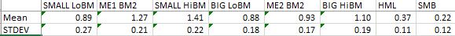

French Website 6 $Size-BM$ Returns

## 7.3 $Size$ and $BM_M$

- Monthly rebalance

```r
df = combine.sources(crsp, comp)
df = df %>% filter(!is.na(L1.ME), !is.na(BMM), BE>0)
```

### 7.3.1 $Size$ Median

```r
quantiles = 1:2/2

nyse = df %>% filter(Exchange=="NYSE") %>% select(Date, PERMNO, L1.ME, BMM)

breakpoints = nyse %>% arrange(Date, L1.ME) %>% group_by(Date) %>% summarize(
    D10=L1.ME[.1*n()], D20=L1.ME[.2*n()],
    D30=L1.ME[.3*n()], D40=L1.ME[.4*n()],
    D50=L1.ME[.5*n()], D60=L1.ME[.6*n()],
    D70=L1.ME[.7*n()], D80=L1.ME[.8*n()],
    D90=L1.ME[.9*n()], D100=L1.ME[n()]) %>% as.data.frame
# breakpoints$Period = breakpoints$Period + 1
breakpoints[, c("PERMNO", "L1.ME")] = NULL
df = left_join(df, breakpoints, by=c("Date"))
df = assign.bkts(df, "L1.ME", quantiles)
```

### 7.3.2 $BM_M$ Quantiles

```r
quantiles = c(.3, .7, 1.)

breakpoints = nyse %>% arrange(Date, BMM) %>% group_by(Date) %>% summarize(
    D10=BMM[.1*n()], D20=BMM[.2*n()],
    D30=BMM[.3*n()], D40=BMM[.4*n()],
    D50=BMM[.5*n()], D60=BMM[.6*n()],
    D70=BMM[.7*n()], D80=BMM[.8*n()],
    D90=BMM[.9*n()], D100=BMM[n()]) %>% as.data.frame
# breakpoints$Period = breakpoints$Period + 1
breakpoints[, c("PERMNO", "BMM")] = NULL
df = left_join(df, breakpoints, by=c("Date"))
df = assign.bkts(df, "BMM", quantiles)
```

```r
df$L1.ME.B = factor(df$L1.ME.B, labels=c("S", "B"))
df$BMM.B = factor(df$BMM.B, labels=c("Lm", "Mm", "Hm"))
```

```r
# df = ri.adj.Size(df)

df = df %>% group_by(L1.ME.B, BMM.B, Date) %>% mutate(
    bkt.L1.ME=sum(L1.ME, na.rm=TRUE)
) %>% as.data.frame
df$wt.ri = df$ri * df$L1.ME / df$bkt.L1.ME
```

### 7.3.3 Returns

```r
df$L1.ME.BMM.B = interaction(df$L1.ME.B, df$BMM.B, sep="")
df$wt.ri = df$wt.ri * 100

returns = df %>% dcast(Date ~ L1.ME.BMM.B, fun.aggregate=sum, value.var="wt.ri", na.rm=TRUE)

returns = returns %>% filter(Date>as.Date("1963-06-30"))

returns$HMLms = returns$SHm - returns$SLm
returns$HMLmb = returns$BHm - returns$BLm
returns$HMLm = (returns$SHm+returns$BHm)/2 - (returns$SLm+returns$BLm)/2
returns$SMB.HMLm = ((returns$SLm+returns$SMm+returns$SHm)/3 -
               (returns$BLm+returns$BMm+returns$BHm)/3)
HMLm = returns %>% select(Date, HMLm, SMB.HMLm)

stat.summary(returns %>% select(-c(Date, `NA`))) %>% round(2)
```

```
##       SLm  BLm  SMm  BMm  SHm  BHm HMLms HMLmb HMLm SMB.HMLm
## [1,] 0.97 0.86 1.17 0.93 1.43 1.14  0.46  0.29 0.37     0.22
## [2,] 0.27 0.18 0.21 0.17 0.25 0.20  0.15  0.14 0.14     0.12
## [3,] 3.67 4.73 5.51 5.41 5.85 5.85  3.02  2.04 2.73     1.81
## [4,] 0.14 0.19 0.22 0.21 0.23 0.23  0.12  0.08 0.11     0.07
```

```r
write.csv(returns, "C:/Data/Thesis/6_L1ME_BMM_Returns.csv")
```

## 7.4 $Size$ and $OP$

- Annual rebalance

```r
df = combine.sources(crsp, comp)
df = df %>% filter(!is.na(Size), OP.OK)
```

### 7.4.1 $Size$ Median

```r
quantiles = 1:2/2

nyse = df %>% filter(Exchange=="NYSE", Month==7) %>% select(Period, PERMNO, Size, OP)

breakpoints = nyse %>% arrange(Period, Size) %>% group_by(Period) %>% summarize(
    D10=Size[.1*n()], D20=Size[.2*n()],
    D30=Size[.3*n()], D40=Size[.4*n()],
    D50=Size[.5*n()], D60=Size[.6*n()],
    D70=Size[.7*n()], D80=Size[.8*n()],
    D90=Size[.9*n()], D100=Size[n()]) %>% as.data.frame
breakpoints$Period = breakpoints$Period + 1
breakpoints[, c("PERMNO", "Size")] = NULL
df = left_join(df, breakpoints, by=c("Period"))
df = assign.bkts(df, "Size", quantiles)
```

### 7.4.2 $OP$ Quantiles

```r
quantiles =c(.3, .7, 1.)

breakpoints = nyse %>% arrange(Period, OP) %>% group_by(Period) %>% summarize(
    D10=OP[.1*n()], D20=OP[.2*n()],
    D30=OP[.3*n()], D40=OP[.4*n()],
    D50=OP[.5*n()], D60=OP[.6*n()],
    D70=OP[.7*n()], D80=OP[.8*n()],
    D90=OP[.9*n()], D100=OP[n()]) %>% as.data.frame
breakpoints$Period = breakpoints$Period + 1
breakpoints[, c("PERMNO", "OP")] = NULL
df = left_join(df, breakpoints, by=c("Period"))
df = assign.bkts(df, "OP", quantiles)
```

```r
df$Size.B = factor(df$Size.B, labels=c("S", "B"))
df$OP.B = factor(df$OP.B, labels=c("Wo", "Mo", "Ro"))
```

```r
# df = ri.adj.Size(df)

df = df %>% group_by(Size.B, OP.B, Date) %>% mutate(
    adj.bkt.Size=sum(adj.Size, na.rm=TRUE)
) %>% as.data.frame
df$wt.ri = df$ri * df$adj.Size / df$adj.bkt.Size
```

### 7.4.3 Returns

```r
df$Size.OP.B = interaction(df$Size.B, df$OP.B, sep="")
df$wt.ri = df$wt.ri * 100

returns = df %>% dcast(Date ~ Size.OP.B, fun.aggregate=sum, value.var="wt.ri", na.rm=TRUE)

returns = returns %>% filter(Date>as.Date("1963-06-30"))

returns$RMWos = returns$SRo - returns$SWo
returns$RMWob = returns$BRo - returns$BWo
returns$RMWo = (returns$SRo+returns$BRo)/2 - (returns$SWo+returns$BWo)/2
returns$SMB.RMWo = ((returns$SWo+returns$SMo+returns$SRo)/3 -
               (returns$BWo+returns$BMo+returns$BRo)/3)
RMWo = returns %>% select(Date, RMWo, SMB.RMWo)

stat.summary(returns %>% select(-c(Date, `NA`))) %>% round(2)
```

```
##       SWo  BWo  SMo  BMo  SRo  BRo RMWos RMWob RMWo SMB.RMWo
## [1,] 0.97 0.76 1.25 0.89 1.28 0.97  0.31  0.21 0.26     0.29
## [2,] 0.25 0.20 0.20 0.17 0.23 0.17  0.11  0.10 0.09     0.11
## [3,] 3.82 3.87 6.09 5.19 5.62 5.73  2.95  2.22 3.03     2.57
## [4,] 0.15 0.15 0.24 0.20 0.22 0.23  0.12  0.09 0.12     0.10
```

```r
write.csv(returns, "C:/Data/Thesis/6_Size_OP_Returns.csv")
```

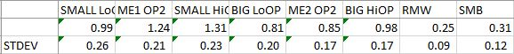

French Website 6 $Size-OP$ Returns

## 7.5 $Size$ and $OP.2$

- Annual rebalance

```r
df = combine.sources(crsp, comp)
df = df %>% filter(!is.na(Size), OP.OK)
```

### 7.5.1 $Size$ Median

```r
quantiles = 1:2/2

nyse = df %>% filter(Exchange=="NYSE", Month==7) %>% select(Period, PERMNO, Size, OP.2)

breakpoints = nyse %>% arrange(Period, Size) %>% group_by(Period) %>% summarize(
    D10=Size[.1*n()], D20=Size[.2*n()],
    D30=Size[.3*n()], D40=Size[.4*n()],
    D50=Size[.5*n()], D60=Size[.6*n()],
    D70=Size[.7*n()], D80=Size[.8*n()],
    D90=Size[.9*n()], D100=Size[n()]) %>% as.data.frame
breakpoints$Period = breakpoints$Period + 1
breakpoints[, c("PERMNO", "Size")] = NULL
df = left_join(df, breakpoints, by=c("Period"))
df = assign.bkts(df, "Size", quantiles)
```

### 7.5.2 $OP.2$ Quantiles

```r
quantiles =c(.3, .7, 1.)

breakpoints = nyse %>% arrange(Period, OP.2) %>% group_by(Period) %>% summarize(
    D10=OP.2[.1*n()], D20=OP.2[.2*n()],
    D30=OP.2[.3*n()], D40=OP.2[.4*n()],
    D50=OP.2[.5*n()], D60=OP.2[.6*n()],
    D70=OP.2[.7*n()], D80=OP.2[.8*n()],
    D90=OP.2[.9*n()], D100=OP.2[n()]) %>% as.data.frame
breakpoints$Period = breakpoints$Period + 1
breakpoints[, c("PERMNO", "OP.2")] = NULL
df = left_join(df, breakpoints, by=c("Period"))
df = assign.bkts(df, "OP.2", quantiles)
```

```r
df$Size.B = factor(df$Size.B, labels=c("S", "B"))
df$OP.2.B = factor(df$OP.2.B, labels=c("Wor", "Mor", "Ror"))

df = df %>% group_by(Size.B, OP.2.B, Date) %>% mutate(
    adj.bkt.Size=sum(adj.Size, na.rm=TRUE)
) %>% as.data.frame
df$wt.ri = df$ri * df$adj.Size / df$adj.bkt.Size
```

### 7.5.3 Returns

```r
df$Size.OP.2.B = interaction(df$Size.B, df$OP.2.B, sep="")
df$wt.ri = df$wt.ri * 100

returns = df %>% dcast(Date ~ Size.OP.2.B, fun.aggregate=sum, value.var="wt.ri", na.rm=TRUE)

returns = returns %>% filter(Date>as.Date("1963-06-30"))

returns$RMWors = returns$SRor - returns$SWor
returns$RMWorb = returns$BRor - returns$BWor
returns$RMWor = (returns$SRor+returns$BRor)/2 - (returns$SWor+returns$BWor)/2
returns$SMB.RMWor = ((returns$SWor+returns$SMor+returns$SRor)/3 -
               (returns$BWor+returns$BMor+returns$BRor)/3)
RMWor = returns %>% select(Date, RMWor, SMB.RMWor)

stat.summary(returns %>% select(-c(Date, `NA`))) %>% round(2)
```

```
##      SWor BWor SMor BMor SRor BRor RMWors RMWorb RMWor SMB.RMWor
## [1,] 0.93 0.73 1.21 0.89 1.35 0.97   0.43   0.24  0.33      0.30
## [2,] 0.24 0.19 0.21 0.17 0.24 0.17   0.07   0.09  0.07      0.12
## [3,] 3.82 3.92 5.85 5.20 5.60 5.59   5.77   2.71  4.95      2.52
## [4,] 0.15 0.15 0.23 0.21 0.22 0.22   0.23   0.11  0.20      0.10
```

```r
write.csv(returns, "C:/Data/Thesis/6_Size_OP_RnD_Returns.csv")
```

## 7.6 $Size$ and $GP$

- Annual rebalance

```r
df = combine.sources(crsp, comp)
df = df %>% filter(!is.na(Size), !is.na(GP))
```

### 7.6.1 $Size$ Median

```r
quantiles = 1:2/2

nyse = df %>% filter(Exchange=="NYSE", Month==7) %>% select(Period, PERMNO, Size, GP)

breakpoints = nyse %>% arrange(Period, Size) %>% group_by(Period) %>% summarize(
    D10=Size[.1*n()], D20=Size[.2*n()],
    D30=Size[.3*n()], D40=Size[.4*n()],
    D50=Size[.5*n()], D60=Size[.6*n()],
    D70=Size[.7*n()], D80=Size[.8*n()],
    D90=Size[.9*n()], D100=Size[n()]) %>% as.data.frame
breakpoints$Period = breakpoints$Period + 1
breakpoints[, c("PERMNO", "Size")] = NULL
df = left_join(df, breakpoints, by=c("Period"))
df = assign.bkts(df, "Size", quantiles)
```

### 7.6.2 $GP$ Quantiles

```r
quantiles =c(.3, .7, 1.)

breakpoints = nyse %>% arrange(Period, GP) %>% group_by(Period) %>% summarize(
    D10=GP[.1*n()], D20=GP[.2*n()],
    D30=GP[.3*n()], D40=GP[.4*n()],
    D50=GP[.5*n()], D60=GP[.6*n()],
    D70=GP[.7*n()], D80=GP[.8*n()],
    D90=GP[.9*n()], D100=GP[n()]) %>% as.data.frame
breakpoints$Period = breakpoints$Period + 1
breakpoints[, c("PERMNO", "GP")] = NULL
df = left_join(df, breakpoints, by=c("Period"))
df = assign.bkts(df, "GP", quantiles)
```

```r
df$Size.B = factor(df$Size.B, labels=c("S", "B"))
df$GP.B = factor(df$GP.B, labels=c("Wg", "Mg", "Rg"))
```

```r
# df = ri.adj.Size(df)

df = df %>% group_by(Size.B, GP.B, Date) %>% mutate(
    adj.bkt.Size=sum(adj.Size, na.rm=TRUE)
) %>% as.data.frame
df$wt.ri = df$ri * df$adj.Size / df$adj.bkt.Size
```

### 7.6.3 Returns

```r
df$Size.GP.B = interaction(df$Size.B, df$GP.B, sep="")
df$wt.ri = df$wt.ri * 100

returns = df %>% dcast(Date ~ Size.GP.B, fun.aggregate=sum, value.var="wt.ri", na.rm=TRUE)

returns = returns %>% filter(Date>as.Date("1963-06-30"))

returns$RMWgs = returns$SRg - returns$SWg
returns$RMWgb = returns$BRg - returns$BWg
returns$RMWg = (returns$SRg+returns$BRg)/2 - (returns$SWg+returns$BWg)/2
returns$SMB.RMWg = ((returns$SWg+returns$SMg+returns$SRg)/3 -
               (returns$BWg+returns$BMg+returns$BRg)/3)
RMWg = returns %>% select(Date, RMWg, SMB.RMWg)

stat.summary(returns %>% select(-c(Date, `NA`))) %>% round(2)
```

```
##       SWg  BWg  SMg  BMg  SRg  BRg RMWgs RMWgb RMWg SMB.RMWg
## [1,] 1.01 0.83 1.15 0.85 1.29 1.02  0.28  0.19 0.24     0.25
## [2,] 0.21 0.18 0.24 0.18 0.24 0.18  0.09  0.11 0.09     0.12
## [3,] 4.74 4.49 4.78 4.80 5.32 5.76  2.96  1.71 2.66     2.04
## [4,] 0.19 0.18 0.19 0.19 0.21 0.23  0.12  0.07 0.11     0.08
```

```r
write.csv(returns, "C:/Data/Thesis/6_Size_GP_Returns.csv")
```

## 7.7 $Size$ and $CP$

- Annual rebalance

```r
df = combine.sources(crsp, comp)
df = df %>% filter(!is.na(Size), OP.OK)
```

### 7.7.1 $Size$ Median

```r
quantiles = 1:2/2

nyse = df %>% filter(Exchange=="NYSE", Month==7) %>% select(Period, PERMNO, Size, CP)

breakpoints = nyse %>% arrange(Period, Size) %>% group_by(Period) %>% summarize(
    D10=Size[.1*n()], D20=Size[.2*n()],
    D30=Size[.3*n()], D40=Size[.4*n()],
    D50=Size[.5*n()], D60=Size[.6*n()],
    D70=Size[.7*n()], D80=Size[.8*n()],
    D90=Size[.9*n()], D100=Size[n()]) %>% as.data.frame
breakpoints$Period = breakpoints$Period + 1
breakpoints[, c("PERMNO", "Size")] = NULL
df = left_join(df, breakpoints, by=c("Period"))
df = assign.bkts(df, "Size", quantiles)
```

### 7.7.2 $CP$ Quantiles

```r
quantiles =c(.3, .7, 1.)

breakpoints = nyse %>% arrange(Period, CP) %>% group_by(Period) %>% summarize(
    D10=CP[.1*n()], D20=CP[.2*n()],
    D30=CP[.3*n()], D40=CP[.4*n()],
    D50=CP[.5*n()], D60=CP[.6*n()],
    D70=CP[.7*n()], D80=CP[.8*n()],
    D90=CP[.9*n()], D100=CP[n()]) %>% as.data.frame
breakpoints$Period = breakpoints$Period + 1
breakpoints[, c("PERMNO", "CP")] = NULL
df = left_join(df, breakpoints, by=c("Period"))
df = assign.bkts(df, "CP", quantiles)
```

```r
df$Size.B = factor(df$Size.B, labels=c("S", "B"))
df$CP.B = factor(df$CP.B, labels=c("Wc", "Mc", "Rc"))
```

```r
# df = ri.adj.Size(df)

df = df %>% group_by(Size.B, CP.B, Date) %>% mutate(
    adj.bkt.Size=sum(adj.Size, na.rm=TRUE)
) %>% as.data.frame
df$wt.ri = df$ri * df$adj.Size / df$adj.bkt.Size
```

### 7.7.3 Returns

```r
df$Size.CP.B = interaction(df$Size.B, df$CP.B, sep="")
df$wt.ri = df$wt.ri * 100

returns = df %>% dcast(Date ~ Size.CP.B, fun.aggregate=sum, value.var="wt.ri", na.rm=TRUE)

returns = returns %>% filter(Date>as.Date("1963-06-30"))

returns$RMWcs = returns$SRc - returns$SWc
returns$RMWcb = returns$BRc - returns$BWc
returns$RMWc = (returns$SRc+returns$BRc)/2 - (returns$SWc+returns$BWc)/2
returns$SMB.RMWc = ((returns$SWc+returns$SMc+returns$SRc)/3 -
               (returns$BWc+returns$BMc+returns$BRc)/3)
RMWc = returns %>% select(Date, RMWc, SMB.RMWc)

stat.summary(returns %>% select(-c(Date, `NA`))) %>% round(2)
```

```
##       SWc  BWc  SMc  BMc  SRc  BRc RMWcs RMWcb RMWc SMB.RMWc
## [1,] 0.87 0.73 1.24 0.84 1.40 1.03  0.53  0.29 0.41     0.30
## [2,] 0.24 0.20 0.21 0.17 0.23 0.17  0.06  0.08 0.06     0.12
## [3,] 3.58 3.75 5.81 5.01 6.13 5.97  8.75  3.53 7.38     2.57
## [4,] 0.14 0.15 0.23 0.20 0.24 0.24  0.35  0.14 0.29     0.10
```

```r
write.csv(returns, "C:/Data/Thesis/6_Size_CP_Returns.csv")
```

## 7.8 $Size$ and $INV$

- Annual rebalance

### 7.8.1 PPE

```r
df = combine.sources(crsp, comp)
df$INV = df$INV.ppe
df = df %>% filter(!is.na(Size), !is.na(INV))
```

### 7.8.2 $Size$ Median

```r
quantiles = 1:2/2

nyse = df %>% filter(Exchange=="NYSE", Month==7) %>% select(Period, PERMNO, Size, INV)

breakpoints = nyse %>% arrange(Period, Size) %>% group_by(Period) %>% summarize(
    D10=Size[.1*n()], D20=Size[.2*n()],
    D30=Size[.3*n()], D40=Size[.4*n()],
    D50=Size[.5*n()], D60=Size[.6*n()],
    D70=Size[.7*n()], D80=Size[.8*n()],
    D90=Size[.9*n()], D100=Size[n()]) %>% as.data.frame
breakpoints$Period = breakpoints$Period + 1
breakpoints[, c("PERMNO", "Size")] = NULL
df = left_join(df, breakpoints, by=c("Period"))
df = assign.bkts(df, "Size", quantiles)
```

### 7.8.3 $INV$ Quantiles

```r
quantiles = c(.3, .7, 1.)

breakpoints = nyse %>% arrange(Period, INV) %>% group_by(Period) %>% summarize(
    D10=INV[.1*n()], D20=INV[.2*n()],
    D30=INV[.3*n()], D40=INV[.4*n()],
    D50=INV[.5*n()], D60=INV[.6*n()],
    D70=INV[.7*n()], D80=INV[.8*n()],
    D90=INV[.9*n()], D100=INV[n()]) %>% as.data.frame
breakpoints$Period = breakpoints$Period + 1
breakpoints[, c("PERMNO", "INV")] = NULL
df = left_join(df, breakpoints, by=c("Period"))
df = assign.bkts(df, "INV", quantiles)
```

```r
df$Size.B = factor(df$Size.B, labels=c("S", "B"))
df$INV.B = factor(df$INV.B, labels=c("C", "M", "A"))
```

```r
# df = ri.adj.Size(df)

df = df %>% group_by(Size.B, INV.B, Date) %>% mutate(
    adj.bkt.Size=sum(adj.Size, na.rm=TRUE)
) %>% as.data.frame
df$wt.ri = df$ri * df$adj.Size / df$adj.bkt.Size
```

### 7.8.4 Returns

```r
df$Size.INV.B = interaction(df$Size.B, df$INV.B, sep="")
df$wt.ri = df$wt.ri * 100

returns = df %>% dcast(Date ~ Size.INV.B, fun.aggregate=sum, value.var="wt.ri", na.rm=TRUE)

returns = returns %>% filter(Date>as.Date("1963-06-30"))

returns$CMAs = returns$SC - returns$SA
returns$CMAb = returns$BC - returns$BA
returns$CMA = (returns$SC+returns$BC)/2 - (returns$SA+returns$BA)/2
returns$SMB.CMA = ((returns$SC+returns$SM+returns$SA)/3 -
               (returns$BC+returns$BM+returns$BA)/3)
CMA = returns %>% select(Date, CMA, SMB.CMA)

stat.summary(returns %>% select(-c(Date, `NA`))) %>% round(2)
```

```
##        SC   BC   SM   BM   SA   BA CMAs CMAb  CMA SMB.CMA
## [1,] 1.28 0.93 1.30 0.93 1.01 0.87 0.27 0.05 0.16    0.29
## [2,] 0.21 0.16 0.22 0.16 0.26 0.20 0.09 0.12 0.09    0.12
## [3,] 6.05 5.86 6.01 5.77 3.95 4.26 3.19 0.47 1.78    2.39
## [4,] 0.24 0.23 0.24 0.23 0.16 0.17 0.13 0.02 0.07    0.09
```

```r
write.csv(returns, "C:/Data/Thesis/6_Size_INV_PPE_Returns.csv")
```

### 7.8.5 Assets

```r
df = combine.sources(crsp, comp)
df = df %>% filter(!is.na(Size), !is.na(INV))
```

### 7.8.6 $Size$ Median

```r
quantiles = 1:2/2

nyse = df %>% filter(Exchange=="NYSE", Month==7) %>% select(Period, PERMNO, Size, INV)

breakpoints = nyse %>% arrange(Period, Size) %>% group_by(Period) %>% summarize(
    D10=Size[.1*n()], D20=Size[.2*n()],
    D30=Size[.3*n()], D40=Size[.4*n()],
    D50=Size[.5*n()], D60=Size[.6*n()],
    D70=Size[.7*n()], D80=Size[.8*n()],
    D90=Size[.9*n()], D100=Size[n()]) %>% as.data.frame
breakpoints$Period = breakpoints$Period + 1
breakpoints[, c("PERMNO", "Size")] = NULL
df = left_join(df, breakpoints, by=c("Period"))
df = assign.bkts(df, "Size", quantiles)
```

### 7.8.7 $INV$ Quantiles

```r
quantiles = c(.3, .7, 1.)

breakpoints = nyse %>% arrange(Period, INV) %>% group_by(Period) %>% summarize(
    D10=INV[.1*n()], D20=INV[.2*n()],
    D30=INV[.3*n()], D40=INV[.4*n()],
    D50=INV[.5*n()], D60=INV[.6*n()],
    D70=INV[.7*n()], D80=INV[.8*n()],
    D90=INV[.9*n()], D100=INV[n()]) %>% as.data.frame
breakpoints$Period = breakpoints$Period + 1
breakpoints[, c("PERMNO", "INV")] = NULL
df = left_join(df, breakpoints, by=c("Period"))
df = assign.bkts(df, "INV", quantiles)
```

```r
df$Size.B = factor(df$Size.B, labels=c("S", "B"))
df$INV.B = factor(df$INV.B, labels=c("C", "M", "A"))
```

```r
# df = ri.adj.Size(df)

df = df %>% group_by(Size.B, INV.B, Date) %>% mutate(
    adj.bkt.Size=sum(adj.Size, na.rm=TRUE)
) %>% as.data.frame
df$wt.ri = df$ri * df$adj.Size / df$adj.bkt.Size
```

### 7.8.8 Returns

```r
df$Size.INV.B = interaction(df$Size.B, df$INV.B, sep="")
df$wt.ri = df$wt.ri * 100

returns = df %>% dcast(Date ~ Size.INV.B, fun.aggregate=sum, value.var="wt.ri", na.rm=TRUE)

returns = returns %>% filter(Date>as.Date("1963-06-30"))

returns$CMAs = returns$SC - returns$SA
returns$CMAb = returns$BC - returns$BA
returns$CMA = (returns$SC+returns$BC)/2 - (returns$SA+returns$BA)/2
returns$SMB.CMA = ((returns$SC+returns$SM+returns$SA)/3 -
               (returns$BC+returns$BM+returns$BA)/3)
CMA = returns %>% select(Date, CMA, SMB.CMA)

stat.summary(returns %>% select(-c(Date, `NA`))) %>% round(2)
```

```
##        SC   BC   SM   BM   SA   BA CMAs CMAb  CMA SMB.CMA
## [1,] 1.30 1.08 1.29 0.92 0.99 0.83 0.31 0.25 0.28    0.25
## [2,] 0.24 0.17 0.20 0.16 0.25 0.20 0.07 0.10 0.07    0.12
## [3,] 5.50 6.27 6.45 5.79 4.03 4.18 4.23 2.56 3.90    2.11
## [4,] 0.22 0.25 0.25 0.23 0.16 0.17 0.17 0.10 0.15    0.08
```

```r
write.csv(returns, "C:/Data/Thesis/6_Size_INV_Returns.csv")
```

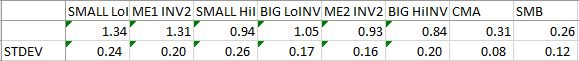

French Website 6 $Size-INV$ Returns

## 7.9 $Size$ and $Prior$

- Monthly rebalance

```r
df = combine.sources(crsp, comp)
df = df %>% filter(!is.na(L1.ME), !is.na(Prior), !is.na(L13.price), !is.na(L1.ri))
```

### 7.9.1 $Size$ Median

```r
quantiles = 1:2/2

nyse = df %>% filter(Exchange=="NYSE") %>% select(Date, PERMNO, L1.ME, Prior)

breakpoints = nyse %>% arrange(Date, L1.ME) %>% group_by(Date) %>% summarize(
    D10=L1.ME[.1*n()], D20=L1.ME[.2*n()],
    D30=L1.ME[.3*n()], D40=L1.ME[.4*n()],
    D50=L1.ME[.5*n()], D60=L1.ME[.6*n()],
    D70=L1.ME[.7*n()], D80=L1.ME[.8*n()],
    D90=L1.ME[.9*n()], D100=L1.ME[n()]) %>% as.data.frame
# breakpoints$Period = breakpoints$Period + 1
breakpoints[, c("PERMNO", "L1.ME")] = NULL
df = left_join(df, breakpoints, by=c("Date"))
df = assign.bkts(df, "L1.ME", quantiles)
```

### 7.9.2 $Prior$ Quantiles

```r
quantiles = c(.3, .7, 1.)

breakpoints = nyse %>% arrange(Date, Prior) %>% group_by(Date) %>% summarize(
    D10=Prior[.1*n()], D20=Prior[.2*n()],
    D30=Prior[.3*n()], D40=Prior[.4*n()],
    D50=Prior[.5*n()], D60=Prior[.6*n()],
    D70=Prior[.7*n()], D80=Prior[.8*n()],
    D90=Prior[.9*n()], D100=Prior[n()]) %>% as.data.frame
# breakpoints$Period = breakpoints$Period + 1
breakpoints[, c("PERMNO", "Prior")] = NULL
df = left_join(df, breakpoints, by=c("Date"))
df = assign.bkts(df, "Prior", quantiles)
```

```r
df$L1.ME.B = factor(df$L1.ME.B, labels=c("S", "B"))
df$Prior.B = factor(df$Prior.B, labels=c("L", "M", "W"))
```

```r
# df = ri.adj.Size(df)

df = df %>% group_by(L1.ME.B, Prior.B, Date) %>% mutate(
    bkt.L1.ME=sum(L1.ME, na.rm=TRUE)
) %>% as.data.frame
df$wt.ri = df$ri * df$L1.ME / df$bkt.L1.ME
```

### 7.9.3 Returns

```r
df$L1.ME.Prior.B = interaction(df$L1.ME.B, df$Prior.B, sep="")
df$wt.ri = df$wt.ri * 100

returns = df %>% dcast(Date ~ L1.ME.Prior.B, fun.aggregate=sum, value.var="wt.ri", na.rm=TRUE)

returns$WMLs = returns$SW - returns$SL
returns$WMLb = returns$BW - returns$BL
returns$WML = (returns$SW+returns$BW)/2 - (returns$SL+returns$BL)/2
returns$SMB.WML = ((returns$SL+returns$SM+returns$SW)/3 -
               (returns$BL+returns$BM+returns$BW)/3)
WML = returns %>% select(Date, WML, SMB.WML)

stat.summary(returns %>% select(-c(Date, `NA`))) %>% round(2)
```

```
##        SL   BL   SM   BM   SW   BW WMLs WMLb  WML SMB.WML
## [1,] 0.71 0.79 1.20 0.86 1.55 1.16 0.84 0.38 0.61    0.22
## [2,] 0.27 0.22 0.20 0.16 0.24 0.19 0.15 0.17 0.16    0.11
## [3,] 2.66 3.61 5.93 5.27 6.33 6.04 5.42 2.15 3.87    1.92
## [4,] 0.10 0.14 0.23 0.21 0.25 0.24 0.21 0.08 0.15    0.08
```

```r
write.csv(returns, "C:/Data/Thesis/25_L1ME_Prior_Returns.csv")
```

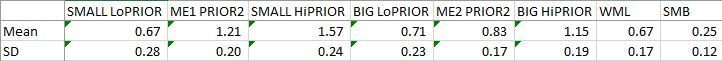

French Website 6 $Size-Prior$ Returns

# 8 Summarise Factors

```r
f = left_join(HML, HMLm, by="Date")
f = left_join(f, RMWo, by="Date")
f = left_join(f, RMWor, by="Date")
f = left_join(f, RMWg, by="Date")
f = left_join(f, RMWc, by="Date")
f = left_join(f, CMA, by="Date")
f = left_join(f, WML, by="Date")
f = left_join(f, rm, by="Date")
f$SMB = (f$SMB.HML + f$SMB.RMWo + f$SMB.CMA) / 3

stat.summary(
    f %>% select(
        -c(Date, SMB.HML, SMB.HMLm, SMB.RMWo, SMB.RMWor, SMB.RMWc, SMB.RMWg, SMB.CMA, SMB.WML)
    )
) %>% round(2)
```

```
##       HML HMLm RMWo RMWor RMWg RMWc  CMA  WML   Rm  SMB
## [1,] 0.32 0.37 0.26  0.33 0.24 0.41 0.28 0.61 0.50 0.26
## [2,] 0.11 0.14 0.09  0.07 0.09 0.06 0.07 0.16 0.17 0.12
## [3,] 2.89 2.73 3.03  4.95 2.66 7.38 3.90 3.82 2.84 2.21
## [4,] 0.11 0.11 0.12  0.20 0.11 0.29 0.15 0.15 0.11 0.09
```

```r
write.csv(f, "C:/Data/Thesis/factors.csv")
```

```r
cor(
    f %>% select(
        -c(Date, SMB.HML, SMB.HMLm, SMB.RMWo, SMB.RMWor, SMB.RMWg, SMB.CMA, SMB.WML)
    )
) %>% round(2) %>% as.data.frame
```

|  | HML | HMLm | RMWo | RMWor | RMWg | RMWc | SMB.RMWc | CMA | WML | Rm | SMB |
| --- | --- | --- | --- | --- | --- | --- | --- | --- | --- | --- | --- |
| HML | 1.00 | 0.79 | 0.12 | -0.33 | -0.59 | -0.22 | -0.12 | 0.65 | -0.22 | -0.33 | -0.12 |
| HMLm | 0.79 | 1.00 | 0.03 | -0.37 | -0.51 | -0.34 | -0.08 | 0.48 | -0.68 | -0.16 | -0.06 |
| RMWo | 0.12 | 0.03 | 1.00 | 0.78 | 0.24 | 0.63 | -0.35 | -0.14 | 0.01 | -0.23 | -0.35 |
| RMWor | -0.33 | -0.37 | 0.78 | 1.00 | 0.62 | 0.78 | -0.11 | -0.36 | 0.16 | -0.01 | -0.13 |
| RMWg | -0.59 | -0.51 | 0.24 | 0.62 | 1.00 | 0.54 | 0.17 | -0.41 | 0.14 | 0.14 | 0.16 |
| RMWc | -0.22 | -0.34 | 0.63 | 0.78 | 0.54 | 1.00 | -0.19 | -0.14 | 0.24 | -0.24 | -0.24 |
| SMB.RMWc | -0.12 | -0.08 | -0.35 | -0.11 | 0.17 | -0.19 | 1.00 | -0.01 | 0.07 | 0.26 | 0.99 |
| CMA | 0.65 | 0.48 | -0.14 | -0.36 | -0.41 | -0.14 | -0.01 | 1.00 | -0.08 | -0.35 | -0.03 |
| WML | -0.22 | -0.68 | 0.01 | 0.16 | 0.14 | 0.24 | 0.07 | -0.08 | 1.00 | -0.05 | 0.04 |
| Rm | -0.33 | -0.16 | -0.23 | -0.01 | 0.14 | -0.24 | 0.26 | -0.35 | -0.05 | 1.00 | 0.27 |

[output cut: 1 more lines]

# 9 Asness and Frazzini (2013) Exhibit 6 Regression 1

```r
summary(lm(HML~Rm+SMB+HMLm+WML, data=f))
```

```
##
## Call:
## lm(formula = HML ~ Rm + SMB + HMLm + WML, data = f)
##
## Residuals:
##     Min      1Q  Median      3Q     Max
## -8.8804 -0.6302  0.0226  0.5929  6.3982
##
## Coefficients:
##             Estimate Std. Error t value Pr(>|t|)
## (Intercept) -0.22514    0.04953  -4.546 6.56e-06 ***
## Rm          -0.07078    0.01128  -6.274 6.52e-10 ***
## SMB         -0.04243    0.01644  -2.581   0.0101 *
## HMLm         0.94606    0.01889  50.070  < 2e-16 ***
## WML          0.39874    0.01615  24.695  < 2e-16 ***
## ---
## Signif. codes:  0 '***' 0.001 '**' 0.01 '*' 0.05 '.' 0.1 ' ' 1
##
## Residual standard error: 1.171 on 637 degrees of freedom
## Multiple R-squared:  0.8311, Adjusted R-squared:   0.83
## F-statistic: 783.5 on 4 and 637 DF,  p-value: < 2.2e-16
```

```r
summary(lm(HMLm~Rm+SMB+WML, data=f))
```

```
##
## Call:
## lm(formula = HMLm ~ Rm + SMB + WML, data = f)
##
## Residuals:
##      Min       1Q   Median       3Q      Max
## -11.2879  -1.3268   0.0088   1.3362  13.2740
##
## Coefficients:
##             Estimate Std. Error t value Pr(>|t|)
## (Intercept)  0.80531    0.09876   8.154 1.87e-15 ***
## Rm          -0.15470    0.02283  -6.776 2.82e-11 ***
## SMB          0.02543    0.03444   0.738    0.461
## WML         -0.59701    0.02421 -24.662  < 2e-16 ***
## ---
## Signif. codes:  0 '***' 0.001 '**' 0.01 '*' 0.05 '.' 0.1 ' ' 1
##
## Residual standard error: 2.454 on 638 degrees of freedom
## Multiple R-squared:  0.5014, Adjusted R-squared:  0.499
## F-statistic: 213.8 on 3 and 638 DF,  p-value: < 2.2e-16
```

```r
summary(lm(HMLm~Rm+SMB+HML+WML, data=f))
```

```
##
## Call:
## lm(formula = HMLm ~ Rm + SMB + HML + WML, data = f)
##
## Residuals:
##     Min      1Q  Median      3Q     Max
## -5.4562 -0.5916 -0.0191  0.5563  7.3550
##
## Coefficients:
##             Estimate Std. Error t value Pr(>|t|)
## (Intercept)  0.35293    0.04540   7.774 3.06e-14 ***
## Rm           0.02831    0.01092   2.594  0.00971 **
## SMB          0.04092    0.01552   2.637  0.00857 **
## HML          0.84285    0.01683  50.070  < 2e-16 ***
## WML         -0.45704    0.01126 -40.599  < 2e-16 ***
## ---
## Signif. codes:  0 '***' 0.001 '**' 0.01 '*' 0.05 '.' 0.1 ' ' 1
##
## Residual standard error: 1.106 on 637 degrees of freedom
## Multiple R-squared:  0.899,  Adjusted R-squared:  0.8983
## F-statistic:  1417 on 4 and 637 DF,  p-value: < 2.2e-16
```

# 10 Asness and Frazzini (2013) Exhibit 6 Regression 4

```r
summary(lm(HMLm~Rm+SMB+HML+WML, data=f))
```

```
##
## Call:
## lm(formula = HMLm ~ Rm + SMB + HML + WML, data = f)
##
## Residuals:
##     Min      1Q  Median      3Q     Max
## -5.4562 -0.5916 -0.0191  0.5563  7.3550
##
## Coefficients:
##             Estimate Std. Error t value Pr(>|t|)
## (Intercept)  0.35293    0.04540   7.774 3.06e-14 ***
## Rm           0.02831    0.01092   2.594  0.00971 **
## SMB          0.04092    0.01552   2.637  0.00857 **
## HML          0.84285    0.01683  50.070  < 2e-16 ***
## WML         -0.45704    0.01126 -40.599  < 2e-16 ***
## ---
## Signif. codes:  0 '***' 0.001 '**' 0.01 '*' 0.05 '.' 0.1 ' ' 1
##
## Residual standard error: 1.106 on 637 degrees of freedom
## Multiple R-squared:  0.899,  Adjusted R-squared:  0.8983
## F-statistic:  1417 on 4 and 637 DF,  p-value: < 2.2e-16
```